# A Spatial Framework for Analyzing NFL Offensive Line Play

Load necessary libraries:

```r
library(tidyr)
library(tidyverse)
library(dplyr)
library(data.table)
library(R.utils)
library(ggplot2)
library(ggrepel)
library(ggvoronoi)
library(ggpubr)
library(viridis)
library(pracma)
library(sf)
library(DT)
library(shiny)
library(gridExtra)
library(sfsmisc)
library(useful)
library(MASS)
library(geometry)
library(survival)
```

Below are the links to all the data necessary for the analysis. The `players_df` is adapted from https://www.nfl.com/ data, `game_play_df` and `gameId_conv_df` is adapted from `nflfastR`, and all others are data frames with sample data from the analysis we reproduce below. Notably, `det_area_analysis_df` is empty, because this data set was too large to upload to GitHub, but the function to produce this data is included in this file. The analysis exampled below will largely be oriented around one play whose data was uploaded to GitHub, stored in `week_games_df`. The analysis is originally produced using tracking data from https://github.com/903124/NFL-live-tracking-data/tree/main/output_file.

```r
players_df <- read.csv("https://raw.githubusercontent.com/paulibrahim/NFL-Offensive-Line-Analysis/main/Data/players.csv")
game_play_df <- read.csv("https://raw.githubusercontent.com/paulibrahim/NFL-Offensive-Line-Analysis/main/Data/game_play_index.csv")
gameId_conv_df <- read.csv("https://raw.githubusercontent.com/paulibrahim/NFL-Offensive-Line-Analysis/main/Data/gameId_conversion.csv")
summary_analysis_df <- read.csv("https://raw.githubusercontent.com/paulibrahim/NFL-Offensive-Line-Analysis/main/Data/sum_info_compiled.csv")
play_info_df <- read.csv("https://raw.githubusercontent.com/paulibrahim/NFL-Offensive-Line-Analysis/main/Data/compiled_play_info.csv")
play_info_df$frameId <- NULL
det_area_analysis_df <- data.frame()
compiled_bin_info_df <- read.csv("https://raw.githubusercontent.com/paulibrahim/NFL-Offensive-Line-Analysis/main/Data/comp_bin_info.csv")
names(compiled_bin_info_df)[1] <- "bin_id"
week_games_df <- read.csv("https://raw.githubusercontent.com/paulibrahim/NFL-Offensive-Line-Analysis/main/Data/week_games.csv")
qb_df <- na.omit(players_df[players_df$position=="QB",])
pos_df <- data.frame(nflId=players_df$nflId, PositionAbbr=players_df$position)
```

It should be noted that apart from the analysis presented in the paper, for the sake of speed we present the same methodological analysis using only a one game sample. If you wish to reproduce the entirety of the analysis, download the original tracking data and use all six elements of `file_vec` and `gameId_vec`.  
Below, we show `game_conv_fun`, the function used to convert tracking data into a manipulable form to be used in our analysis. The inputs to this function are `file_vec` and `gameId_vec`. The former is a vector containing the file names of the tracking data to be analyzed in a `csv.gz` format, and the latter is a vector containing the game Id’s associated with the games contained in the `file_vec`.

```r
# setwd("")
file_vec <- c("broncos-at-jets-2020-reg-4.csv.gz", "chargers-at-saints-2020-reg-5.csv.gz",
               "chiefs-at-ravens-2020-reg-3.csv.gz", "eagles-at-49ers-2020-reg-4.csv.gz",
               "falcons-at-packers-2020-reg-4.csv.gz","vikings-at-seahawks-2020-reg-5.csv.gz") #vector of file names, function input
gameId_vec <- c("2020_04_DEN_NYJ", "2020_05_LAC_NO", "2020_03_KC_BAL", "2020_04_PHI_SF", "2020_04_ATL_GB", "2020_05_MIN_SEA") #vector of gameId's corresponding to files, function input

file_vec <- file_vec[1]
gameId_vec <- gameId_vec[1]

#we create this function to convert the raw data into a manipulable form
game_conv_fun <- function(file_vec, gameId_vec){
game_dt_list <- list()
i <- 1
for (file_name in file_vec) {
dt <-  fread(file_name)
dt <- as.data.frame(sapply(dt, function(x) gsub("'", "", x)))
dt <- as.data.frame(sapply(dt, function(x) gsub("\\[", "", x)))
dt <- as.data.frame(sapply(dt, function(x) gsub("\\]", "", x)))

dt$V1 <- as.numeric(as.character(dt$V1))
dt$play_id <- as.numeric(as.character(dt$play_id))

dt_home <- (separate_rows(dt, data.home_player_x_coord,data.home_player_y_coord, data.home_player_id,
                          sep=",", convert = TRUE))
dt_home[ ,c('data.home_player_firstname', 'data.home_player_lastname', 'data.home_player_position',
       'data.home_jersey_number','data.home_jeresy_number','data.home_jerset_number',
       'data.home_jerest_number','data.away_player_x_coord','data.away_player_y_coord',
       'data.away_player_id','data.away_player_firstname','data.away_player_lastname',
       'data.away_player_position','data.away_jersey_number','data.away_jeresy_number',
       'data.away_jerset_number','data.away_jerest_number','data.ball_x','data.ball_y')] <- list(NULL)

dt_home$data.home_player_x_coord <- as.numeric(as.character(dt_home$data.home_player_x_coord))
dt_home$data.home_player_y_coord <- as.numeric(as.character(dt_home$data.home_player_y_coord))
dt_home$data.home_player_id <- as.numeric(as.character(dt_home$data.home_player_id))
dt_home <- dt_home[dt_home$data.home_player_x_coord>30 & dt_home$data.home_player_x_coord<750 & dt_home$data.home_player_y_coord>35 & dt_home$data.home_player_y_coord<350,]

dt_away <- (separate_rows(dt, data.away_player_x_coord,data.away_player_y_coord, data.away_player_id,
                          sep=",", convert = TRUE))
dt_away[ ,c('data.away_player_firstname', 'data.away_player_lastname', 'data.away_player_position',
            'data.away_jersey_number','data.away_jeresy_number','data.away_jerset_number',
            'data.away_jerest_number','data.home_player_x_coord','data.home_player_y_coord',
            'data.home_player_id','data.home_player_firstname','data.home_player_lastname',
            'data.home_player_position','data.home_jersey_number','data.home_jeresy_number',
            'data.home_jerset_number','data.home_jerest_number','data.ball_x','data.ball_y')] <- list(NULL)

dt_away$data.away_player_x_coord <- as.numeric(as.character(dt_away$data.away_player_x_coord))
dt_away$data.away_player_y_coord <- as.numeric(as.character(dt_away$data.away_player_y_coord))
dt_away$data.away_player_id <- as.integer(as.character(dt_away$data.away_player_id))
dt_away <- dt_away[dt_away$data.away_player_x_coord>30 & dt_away$data.away_player_x_coord<750 & dt_away$data.away_player_y_coord>35 & dt_away$data.away_player_y_coord<350,]

dt_ball <- (separate_rows(dt, data.ball_x,data.ball_y,
                          sep=",", convert = TRUE))
dt_ball[ ,c('data.home_player_x_coord', 'data.home_player_y_coord', 'data.home_player_id',
            'data.home_player_firstname','data.home_player_lastname','data.home_player_position',
            'data.home_jersey_number','data.home_jeresy_number','data.home_jerset_number',
            'data.home_jerest_number','data.away_player_x_coord','data.away_player_y_coord',
            'data.away_player_id','data.away_player_firstname','data.away_player_lastname',
            'data.away_player_position','data.away_jersey_number','data.away_jeresy_number',
            'data.away_jerset_number', 'data.away_jerest_number')] <- list(NULL)

dt_ball$data.ball_x <- as.numeric(as.character(dt_ball$data.ball_x))
dt_ball$data.ball_y <- as.numeric(as.character(dt_ball$data.ball_y))
dt_ball <- dt_ball[dt_ball$data.ball_x>30 & dt_ball$data.ball_x<750 & dt_ball$data.ball_y>35 & dt_ball$data.ball_y<350,]
dt_ball$gen_indexer <- 1:nrow(dt_ball)

home_v1_agg <- aggregate(data.home_player_id~V1, dt_home, length)
away_v1_agg <- aggregate(data.away_player_id~V1, dt_away, length)
ball_v1_agg <- aggregate(gen_indexer~V1, dt_ball, length)

home_v1_agg <- home_v1_agg[home_v1_agg$data.home_player_id==11,]
away_v1_agg <- away_v1_agg[away_v1_agg$data.away_player_id==11,]
ball_v1_agg <- ball_v1_agg[ball_v1_agg$gen_indexer==1,]

all_v1_agg <- merge(home_v1_agg, away_v1_agg, by="V1")
all_v1_agg <- merge(all_v1_agg, ball_v1_agg, by="V1")

dt_home <- dt_home[dt_home$V1 %in% all_v1_agg$V1,]
dt_away <- dt_away[dt_away$V1 %in% all_v1_agg$V1,]
dt_ball <- dt_ball[dt_ball$V1 %in% all_v1_agg$V1,]

dt_home <- dt_home[order(dt_home$play_id, dt_home$V1),]
dt_away <- dt_away[order(dt_away$play_id, dt_away$V1),]
dt_ball <- dt_ball[order(dt_ball$play_id, dt_ball$V1),]

dt_home$V2 <- sort(rep(1:(nrow(dt_home)/11), 11))
dt_away$V2 <- sort(rep(1:(nrow(dt_away)/11), 11))
dt_ball$V2 <- sort(rep(1:(nrow(dt_ball)), 1))

home_play_agg <- aggregate(V2~play_id, dt_home, length)
home_play_agg$tot_frames <- (home_play_agg$V2)/11
all_frames_vec <- as.vector(ceiling(1:sum(home_play_agg$tot_frames)/11))
home_play_agg$V2 <- NULL
home_play_agg$tot_frames_cumsum <- c(0,cumsum(home_play_agg$tot_frames)[-length(home_play_agg$tot_frames)])
all_frames_df <- data.frame(play_id=(home_play_agg[rep(row.names(home_play_agg), 11*home_play_agg$tot_frames), 1]), V2=dt_home$V2)
home_play_agg$tot_frames <- NULL
all_frames_df <- merge(all_frames_df, home_play_agg, by="play_id")
all_frames_df$frameId <- all_frames_df$V2-all_frames_df$tot_frames_cumsum
all_frames_df <- all_frames_df[seq(1, nrow(all_frames_df), 11), ]
all_frames_df$tot_frames_cumsum <- NULL
all_frames_df$play_id <- NULL

dt_home <- merge(dt_home, all_frames_df, by=("V2"))
dt_away <- merge(dt_away, all_frames_df, by=("V2"))
dt_ball <- merge(dt_ball, all_frames_df, by=("V2"))

names(dt_home)[names(dt_home) == "data.home_player_x_coord"] <- "x_coords"
names(dt_home)[names(dt_home) == "data.home_player_y_coord"] <- "y_coords"
names(dt_home)[names(dt_home) == "data.home_player_id"] <- "nflId"
dt_home$team <- "home"

names(dt_away)[names(dt_away) == "data.away_player_x_coord"] <- "x_coords"
names(dt_away)[names(dt_away) == "data.away_player_y_coord"] <- "y_coords"
names(dt_away)[names(dt_away) == "data.away_player_id"] <- "nflId"
dt_away$team <- "away"

names(dt_ball)[names(dt_ball) == "data.ball_x"] <- "x_coords"
names(dt_ball)[names(dt_ball) == "data.ball_y"] <- "y_coords"
dt_ball$nflId <- -1
dt_ball$team <- "ball"
dt_ball$gen_indexer <- NULL

dt_all <- bind_rows(dt_home, dt_away, dt_ball)
names(dt_all)[names(dt_all) == "data.event"] <- "event"
names(dt_all)[names(dt_all) == "play_id"] <- "playId"
dt_all$V1 <- NULL
dt_all$V2 <- NULL
dt_all$x_coords <- (dt_all$x_coords-30)/6
dt_all$y_coords <- (dt_all$y_coords-30)/6

dt_all$gameId <- gameId_vec[i]

game_dt_list[[i]] <- dt_all

i <- i+1
}
dt_binded_exp <- rbindlist(game_dt_list)

dt_binded_exp[ ,c('data.pass_chance','data.exact_los','data.exact_first_down')] <- list(NULL)
return(dt_binded_exp)
}

# week_games_df <- game_conv_fun(file_vec, gameId_vec)
```

The `base_vor_fun` function below returns information concerning Voronoi area for each unique inputted frame. The function calls upon the `game_conv_fun` function, and thus inputs `file_vec` and `gameId_vec`, as well as `playId` for our demonstrative analysis (for the sake of speed, we’ll only run the function on one play), though this can be removed and the function can be easily altered to iterate through all plays within the selected sample of games.

```r
base_vor_fun <- function(file_vec, gameId_vec, playId){
  # week_games_df <- game_conv_fun(file_vec, gameId_vec)
  week_games_df$event[week_games_df$event == "Pass Attempt"] <- "pass_forward"
  week_games_df$event[week_games_df$event == "Snap"] <- "ball_snap"

  return_list <- list()
  vor_plot_list <- list()
  vor_info_list <- list()
  k <- 1
  for (game_id in unique(gameId_vec)) {
    # print("game")
    # print(k)
    ind_game_df <- week_games_df[week_games_df$gameId==game_id,]
    ind_game_df <- merge(ind_game_df, game_play_df, by=c("gameId", "playId"))


    ball_df <- ind_game_df[ind_game_df$nflId==-1,]

    pass_forward_events <- (unique((ind_game_df[ind_game_df$play_type=="pass",])$playId))
    pass_forward_events <- pass_forward_events[!is.na(pass_forward_events)]


    pass_forward_info_df <- ind_game_df[ind_game_df$event=="pass_forward" & ind_game_df$playId %in% pass_forward_events,]
    pass_forward_events_df <- aggregate(frameId ~ playId, data = pass_forward_info_df , min)

    vor_plot_play_list <- list()
    vor_info_play_list <- list()
    j <- 1
    for (play_id in unique(playId)) {
      # print("play")
      # print(j)
      full_play_df <- ind_game_df[ind_game_df$playId==play_id,]
      line_set_frame <- min(unique(full_play_df[full_play_df$event=="Line Set",]$frameId))
      if (line_set_frame==Inf) {
        line_set_frame <- min(unique(na.omit(full_play_df[full_play_df$event=="ball_snap",]$frameId)))-1
        if (line_set_frame<1) {
          next
        }
      }
      initial_configuration_df <- full_play_df[full_play_df$frameId==line_set_frame & full_play_df$nflId==-1,]
      spec_frame_id <- pass_forward_events_df[pass_forward_events_df$playId==play_id,]$frameId

      ball_snap_frame <- min(unique(na.omit(full_play_df[full_play_df$event=="ball_snap",]$frameId)))
      pass_forward_frame <- min(unique(na.omit(full_play_df[full_play_df$event=="pass_forward",]$frameId)))

      if (ball_snap_frame==Inf | pass_forward_frame==Inf | line_set_frame==Inf) {
        next
      }

      ball_snap_configuration_df <- full_play_df[full_play_df$frameId==ball_snap_frame & full_play_df$nflId==-1,]

      time_of_pass_df <- full_play_df[full_play_df$frameId==spec_frame_id & full_play_df$nflId==-1,]

      qb_id_df <- full_play_df[full_play_df$nflId %in% qb_df$nflId & full_play_df$frameId==ball_snap_frame,]
      if (nrow(qb_id_df)>1) {
        qb_id_df$ball_dist <- sqrt(((ball_snap_configuration_df$x_coords-qb_id_df$x_coords)^2)+((ball_snap_configuration_df$y_coords-qb_id_df$y_coords)^2))
        qb_id_df <- qb_id_df[qb_id_df$ball_dist==min(qb_id_df$ball_dist),]
      }
      time_of_pass_qb_df <- full_play_df[full_play_df$frameId==spec_frame_id & full_play_df$nflId==qb_id_df$nflId,]

      qb_tot_df <- full_play_df[full_play_df$nflId %in% qb_id_df$nflId & full_play_df$frameId==spec_frame_id,]  #isolating the voronoi coordinates for the quarterback
      LOS_x <- initial_configuration_df$x_coords
      LOS_y <- initial_configuration_df$y_coords

      if (LOS_x>time_of_pass_qb_df$x_coords) {
        field_progress_indicator <- -1

      } else {
        field_progress_indicator <- 1
      }

      norm_full_play_df <- full_play_df
      norm_full_play_df$x_coords <- (full_play_df$x_coords-LOS_x)*-1*field_progress_indicator
      norm_full_play_df$y_coords <- (full_play_df$y_coords-(160/6))*field_progress_indicator
      offensive_team <- unique(norm_full_play_df[norm_full_play_df$nflId %in% qb_df$nflId,]$team)

      time_of_pass_norm_df <- norm_full_play_df[norm_full_play_df$frameId==(spec_frame_id) & norm_full_play_df$nflId==-1,]
      time_before_pass_norm_df <- norm_full_play_df[norm_full_play_df$frameId==(spec_frame_id-1) & norm_full_play_df$nflId==-1,]

      pass_angle <- (atan((time_of_pass_norm_df$x_coords-time_before_pass_norm_df$x_coords)/(time_of_pass_norm_df$y_coords-time_before_pass_norm_df$y_coords)))*(180/pi)
      if (is.na(pass_angle)==TRUE) {
        pass_angle <- NA
      } else if (pass_angle<0) {
        pass_angle <- pass_angle+180
      }

      xbound1 <- -10
      ybound1 <- ((LOS_y-(160/6))*field_progress_indicator)+6
      ybound2 <- ((LOS_y-(160/6))*field_progress_indicator)-6

      play_frame_duration <- (pass_forward_frame-ball_snap_frame)+1

      norm_full_play_in_pocket_df <- norm_full_play_df[norm_full_play_df$nflId!=-1,] #omitting ball from dataframe
      norm_full_play_in_pocket_df <- norm_full_play_in_pocket_df[norm_full_play_in_pocket_df$frameId>=ball_snap_frame & norm_full_play_in_pocket_df$frameId<=pass_forward_frame,]
      norm_full_play_in_pocket_df <- norm_full_play_in_pocket_df[norm_full_play_in_pocket_df$y_coords<ybound1 & norm_full_play_in_pocket_df$y_coords>ybound2,]
      norm_full_play_in_pocket_df <- norm_full_play_in_pocket_df[rowSums(is.na(norm_full_play_in_pocket_df)) != ncol(norm_full_play_in_pocket_df), ]
      full_play_pocket_df <- norm_full_play_in_pocket_df[(norm_full_play_in_pocket_df$x_coords>xbound1 & norm_full_play_in_pocket_df$x_coords<0),]

      y_coord_adj <- (norm_full_play_df[norm_full_play_df$frameId==1 & norm_full_play_df$nflId==-1,]$y_coords)

      player_in_pocket_frame_count_df<- (aggregate(frameId ~ nflId, data = full_play_pocket_df , length))
      player_in_pocket_frame_count_df$freq <- player_in_pocket_frame_count_df$frameId/play_frame_duration
      adj_player_in_pocket_df <- player_in_pocket_frame_count_df[player_in_pocket_frame_count_df$freq>=0.5,]


      pocket_players_at_snap_df <- norm_full_play_df[norm_full_play_df$frameId==ball_snap_frame & norm_full_play_df$nflId %in% adj_player_in_pocket_df$nflId,]
      rel_pos_df <- merge(pocket_players_at_snap_df, pos_df, by="nflId")
      rel_pos_df <- data.frame(nflId=rel_pos_df$nflId, "PositionAbbr"=rel_pos_df$PositionAbbr)
      pocket_players_at_snap_df <- merge(rel_pos_df,pocket_players_at_snap_df, by="nflId", all=T)
      pocket_players_at_snap_df$PositionAbbr[is.na(pocket_players_at_snap_df$PositionAbbr)] <- "UN"
      oline_players_at_snap_df <- pocket_players_at_snap_df[pocket_players_at_snap_df$team==offensive_team & pocket_players_at_snap_df$PositionAbbr!="QB" & pocket_players_at_snap_df$PositionAbbr!="RB",]
      qb_at_snap_df <- pocket_players_at_snap_df[pocket_players_at_snap_df$PositionAbbr=="QB",]
      if (nrow(qb_at_snap_df)==0) {
        next
      }
      qb_in_pocket_df <- adj_player_in_pocket_df[adj_player_in_pocket_df$nflId==qb_at_snap_df$nflId[1],]
      if (qb_in_pocket_df$freq<1) {
        next
      }
```

```r
      oline_players_at_snap_df <- oline_players_at_snap_df[order(oline_players_at_snap_df$y_coords),]
      if (nrow(oline_players_at_snap_df)>0) {
        oline_players_at_snap_df$ordering <- 1:nrow(oline_players_at_snap_df)
      } else {
        oline_players_at_snap_df$ordering <- numeric(nrow(oline_players_at_snap_df))
      }
      oline_ordering_df <- data.frame(nflId=oline_players_at_snap_df$nflId, ordering=oline_players_at_snap_df$ordering)

      voronoi_x_list <- list()
      voronoi_y_list <- list()
      voronoi_nflId_list <- list()
      voronoi_frameid_list <- list()

      voronoi_area_vec <- rep(NA, times=length(ball_snap_frame:max(full_play_df$frameId)))
      rect <- data.frame(x=c(xbound1, 0, 0, xbound1, xbound1), y=c(ybound1, ybound1, ybound2, ybound2, ybound1))

      oline_ordering_wQB_df <- oline_ordering_df
      oline_ordering_wQB_df[nrow(oline_ordering_wQB_df)+1,] <- c(qb_at_snap_df$nflId, 0)


      vor_plot_frame_list <- list()
      vor_info_frame_list <- list()
      i <- 1
      for (frame_id in c(ball_snap_frame:pass_forward_frame)) {
        # print("frame")
        # print(i)

        spec_frame_df <- norm_full_play_df[norm_full_play_df$frameId==frame_id,]
        frame_omit_ball_df <- spec_frame_df[spec_frame_df$nflId!=-1,] #omitting ball from dataframe
        spec_frame_wo_ball_df <- frame_omit_ball_df[frame_omit_ball_df$y_coords<ybound1 & frame_omit_ball_df$y_coords>ybound2,]
        spec_frame_wo_ball_df <- spec_frame_wo_ball_df[rowSums(is.na(spec_frame_wo_ball_df)) != ncol(spec_frame_wo_ball_df), ]

        spec_players_df <- spec_frame_df[spec_frame_df$nflId %in% adj_player_in_pocket_df$nflId,]
        spec_players_df <- (merge(spec_players_df, rel_pos_df, by="nflId", all=T))
        spec_players_df$PositionAbbr[is.na(spec_players_df$PositionAbbr)] <- "UN"

        player_team_df <- data.frame(nflId=spec_players_df$nflId, team=spec_players_df$team)

        off_players_df <- spec_players_df[spec_players_df$team==offensive_team,]
        def_players_df <- frame_omit_ball_df[frame_omit_ball_df$team!=offensive_team,]
        oline_df <- off_players_df[off_players_df$PositionAbbr!="QB" & off_players_df$PositionAbbr!="RB",]
        oline_wQB_df <- off_players_df[off_players_df$PositionAbbr!="RB",]
        oline_df <- merge(oline_df, oline_ordering_df, by="nflId")
        oline_wQB_df <- merge(oline_wQB_df, oline_ordering_wQB_df, by="nflId")
        qb_frame_df <- off_players_df[off_players_df$PositionAbbr=="QB",]

        if (nrow(oline_df)>0) {
          oline_df$relevant_frame <- (oline_df$frameId-ball_snap_frame)+1
          oline_df$players_on_line <- nrow(oline_df)

          oline_wQB_df$relevant_frame <- (oline_wQB_df$frameId-ball_snap_frame)+1
          oline_wQB_df$players_on_line <- nrow(oline_df)
        } else {
          oline_df$relevant_frame = numeric(nrow(oline_df))
          oline_df$players_on_line = numeric(nrow(oline_df))

          oline_wQB_df$relevant_frame = numeric(nrow(oline_wQB_df))
          oline_wQB_df$players_on_line = numeric(nrow(oline_wQB_df))
        }

        pocket_df <- spec_frame_wo_ball_df[(spec_frame_wo_ball_df$x_coords>xbound1 & spec_frame_wo_ball_df$x_coords<0),]
        def_players_df$PositionAbbr <- NULL
        off_vor_calc_df <- spec_frame_wo_ball_df[spec_frame_wo_ball_df$nflId %in% oline_wQB_df$nflId,]

        vor_calc_df <- rbind(off_vor_calc_df, def_players_df)
        vor_calc_df$duplicated <- duplicated(vor_calc_df[,3:4])
        vor_calc_df <- vor_calc_df[vor_calc_df$duplicated==FALSE,]
        vor_calc_df$duplicated <- NULL

        vor_calc_df <- as.data.frame(vor_calc_df)
        vor_spdf <- voronoi_polygon(data=vor_calc_df,x="x_coords",y="y_coords", outline=rect)
        vor_df <- fortify_voronoi(vor_spdf)
        # vor_df <- merge(vor_df, player_guide_df, by=c("nflId"))
        mp_sf <- st_as_sf(vor_spdf)
        p_sf <- st_cast(mp_sf, "POLYGON")
        p_qb_sf <- p_sf[p_sf$nflId==qb_frame_df$nflId,]
        if (nrow(p_qb_sf)==0) {
          next
        }
        p_qb_sf_line <- p_sf[p_sf$team==offensive_team,]
        area <- st_area(p_qb_sf)
        area_line <- sum(st_area(p_qb_sf_line))

        # p_sf <- merge(p_sf, player_guide_df, by=c("nflId"))

        area_info_df <- data.frame(nflId=p_qb_sf$nflId, qb_tot_area=area, line_tot_area=area_line)


        area_info_df$frameId <- frame_id
        area_info_df$playId <- play_id
        area_info_df$gameId <- game_id
        area_info_df$relevant_frame <- (area_info_df$frameId-ball_snap_frame)+1



        p1 <- ggplot() + geom_polygon(data=vor_df, aes(x=y, y=x,group=group,fill=team), color="white")+
          # scale_fill_manual(values = c("firebrick1","purple3"))+
          geom_path(data=rect, aes(x=y, y=x))+
          # geom_point(aes(x=qb_frame_df$y_coords, y=qb_frame_df$x_coords))+
          geom_label_repel(data=p_sf, aes(x=y_coords, y=x_coords, label=nflId, color=team),size=3, fontface = "bold")+
          # theme(legend.position = "none")+
          # scale_color_manual(values = c("black","gold3"))
          guides(color=FALSE, fill=guide_legend(title="Team"))



        vor_plot_frame_list[[i]] <- p1
        vor_info_frame_list[[i]] <- area_info_df


        i <- i+1
      }
      vor_plot_play_list[[j]] <- (vor_plot_frame_list)
      vor_info_play_list[[j]] <- rbindlist(vor_info_frame_list)
      j <- j+1
    }
    vor_plot_list[[k]] <- (vor_plot_play_list)
    vor_info_list[[k]] <- rbindlist(vor_info_play_list)
    k <- k+1
  }
  return_list[[1]] <- vor_plot_list
  return_list[[2]] <- vor_info_list
  return(return_list)
}
```

The `base_vor_fun` function returns a four-dimensional list, where the first inputted dimension of the list dictates whether to return a plot or a data frame (1 returning a plot, 2 returning a data frame). If you are attempting to return a data frame, only return one dimension, with the command `base_vor_fun()[2]`. If you are attempting to return a plot, use all four dimensions, with the second inputted dimension dictating which game to return information from (1 being the first game listed above in `file_vec`, 2 being the second, etc.), the third inputted dimension dictating which play to return information from (1 being the first passing play in the selected game, 2 being the second, etc.), and the fourth inputted dimension dictating which frame to return information from (1 being the first frame after the snap in the selected play, 2 being the second, etc.). In the example below, we produce a Voronoi plot of the pocket 15 frames after the snap in the first passing play of the 1st game of our sample and the play’s corresponding data frame.

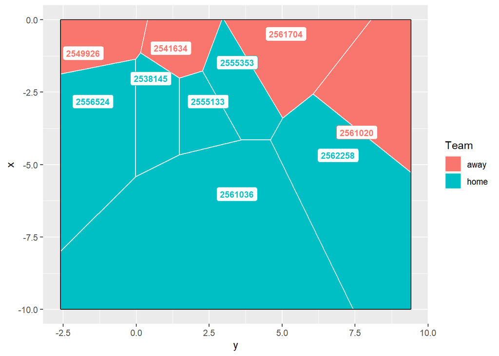

```r
print(base_vor_fun(file_vec[1],gameId_vec[1], 76)[[1]][[1]][[1]][[15]])
```

```r
print(base_vor_fun(file_vec[1],gameId_vec[1], 76)[[2]])
```

```
## [[1]]
##       nflId qb_tot_area line_tot_area frameId playId          gameId
##  1: 2561036    68.50576     117.99614      64     76 2020_04_DEN_NYJ
##  2: 2561036    66.99302     117.80647      65     76 2020_04_DEN_NYJ
##  3: 2561036    65.20761     117.08635      66     76 2020_04_DEN_NYJ
##  4: 2561036    63.46892     116.25668      67     76 2020_04_DEN_NYJ
##  5: 2561036    61.71126     115.27737      68     76 2020_04_DEN_NYJ
##  6: 2561036    59.95518     114.15205      69     76 2020_04_DEN_NYJ
##  7: 2561036    58.22037     112.86017      70     76 2020_04_DEN_NYJ
##  8: 2561036    56.45600     111.17128      71     76 2020_04_DEN_NYJ
##  9: 2561036    54.71630     109.36470      72     76 2020_04_DEN_NYJ
## 10: 2561036    52.98615     107.51260      73     76 2020_04_DEN_NYJ
## 11: 2561036    50.69294     105.14756      74     76 2020_04_DEN_NYJ
## 12: 2561036    48.21517     102.20283      75     76 2020_04_DEN_NYJ
## 13: 2561036    45.94444      98.92891      76     76 2020_04_DEN_NYJ
```

[output cut: 34 more lines]

The `bin_fun` function below returns information concerning bin area for each unique inputted frame. The function calls upon the `game_conv_fun` function, and thus inputs `file_vec` and `gameId_vec`, as well as `playId` for our demonstrative analysis (for the sake of speed, we’ll only run the function on one play), though this can be removed and the function can be easily altered to iterate through all plays within the selected sample of games.

```r
bin_fun <- function(file_vec, gameId_vec, playId){
  # week_games_df <- game_conv_fun(file_vec, gameId_vec)
  week_games_df$event[week_games_df$event == "Pass Attempt"] <- "pass_forward"
  week_games_df$event[week_games_df$event == "Snap"] <- "ball_snap"

  return_list <- list()
  bin_info_game_list <- list()

  k <- 1
  for (game_id in unique(week_games_df$gameId)[1]) {
    # print("game")
    # print(k)
    ind_game_df <- week_games_df[week_games_df$gameId==game_id,]
    ind_game_df <- merge(ind_game_df, game_play_df, by=c("gameId", "playId"))

    ball_df <- ind_game_df[ind_game_df$nflId==-1,]

    pass_forward_events <- (unique((ind_game_df[ind_game_df$play_type=="pass",])$playId))
    pass_forward_events <- pass_forward_events[!is.na(pass_forward_events)]


    pass_forward_info_df <- ind_game_df[ind_game_df$event=="pass_forward" & ind_game_df$playId %in% pass_forward_events,]
    pass_forward_events_df <- aggregate(frameId ~ playId, data = pass_forward_info_df , min)

    qb_vor_area_info_play_list <- list()
    qb_det_vor_area_play_list <- list()
    procrustes_info_play_list <- list()
    bin_info_play_list <- list()


    j <- 1
    for (play_id in unique(pass_forward_events_df$playId)[1]) {
      # print("play")
      # print(j)
      full_play_df <- ind_game_df[ind_game_df$playId==play_id,]
      line_set_frame <- min(unique(full_play_df[full_play_df$event=="Line Set",]$frameId))
      if (line_set_frame==Inf) {
        line_set_frame <- min(unique(na.omit(full_play_df[full_play_df$event=="ball_snap",]$frameId)))-1
        if (line_set_frame<1) {
          next
        }
      }
      initial_configuration_df <- full_play_df[full_play_df$frameId==line_set_frame & full_play_df$nflId==-1,]
      spec_frame_id <- pass_forward_events_df[pass_forward_events_df$playId==play_id,]$frameId

      ball_snap_frame <- min(unique(na.omit(full_play_df[full_play_df$event=="ball_snap",]$frameId)))
      pass_forward_frame <- min(unique(na.omit(full_play_df[full_play_df$event=="pass_forward",]$frameId)))

      if (ball_snap_frame==Inf | pass_forward_frame==Inf | line_set_frame==Inf) {
        next
      }

      ball_snap_configuration_df <- full_play_df[full_play_df$frameId==ball_snap_frame & full_play_df$nflId==-1,]

      time_of_pass_df <- full_play_df[full_play_df$frameId==spec_frame_id & full_play_df$nflId==-1,]

      qb_id_df <- full_play_df[full_play_df$nflId %in% qb_df$nflId & full_play_df$frameId==ball_snap_frame,]
      if (nrow(qb_id_df)>1) {
        qb_id_df$ball_dist <- sqrt(((ball_snap_configuration_df$x_coords-qb_id_df$x_coords)^2)+((ball_snap_configuration_df$y_coords-qb_id_df$y_coords)^2))
        qb_id_df <- qb_id_df[qb_id_df$ball_dist==min(qb_id_df$ball_dist),]
      }
      time_of_pass_qb_df <- full_play_df[full_play_df$frameId==spec_frame_id & full_play_df$nflId==qb_id_df$nflId,]

      qb_tot_df <- full_play_df[full_play_df$nflId %in% qb_id_df$nflId & full_play_df$frameId==spec_frame_id,]  #isolating the voronoi coordinates for the quarterback
      LOS_x <- initial_configuration_df$x_coords
      LOS_y <- initial_configuration_df$y_coords

      if (LOS_x>time_of_pass_qb_df$x_coords) {
        field_progress_indicator <- -1 ####make this value 1 or -1, calculate in play_id for loop. -1 means LOS_x>qb initial position, 1 means LOS_x<qb initial position

      } else {
        field_progress_indicator <- 1
      }

      norm_full_play_df <- full_play_df
      norm_full_play_df$x_coords <- (full_play_df$x_coords-LOS_x)*-1*field_progress_indicator
      norm_full_play_df$y_coords <- (full_play_df$y_coords-(160/6))*field_progress_indicator
      offensive_team <- unique(norm_full_play_df[norm_full_play_df$nflId %in% qb_df$nflId,]$team)

      time_of_pass_norm_df <- norm_full_play_df[norm_full_play_df$frameId==(spec_frame_id) & norm_full_play_df$nflId==-1,]
      time_before_pass_norm_df <- norm_full_play_df[norm_full_play_df$frameId==(spec_frame_id-10) & norm_full_play_df$nflId==-1,]
      time_after_pass_norm_df <- norm_full_play_df[norm_full_play_df$frameId==(spec_frame_id+10) & norm_full_play_df$nflId==-1,]

      if (nrow(time_of_pass_norm_df)==0 | nrow(time_after_pass_norm_df)==0) {
        pass_angle <- NA
      } else {
        pass_angle <- (atan((time_of_pass_norm_df$x_coords-time_after_pass_norm_df$x_coords)/(time_of_pass_norm_df$y_coords-time_after_pass_norm_df$y_coords)))*(180/pi)
        if (is.na(pass_angle)==TRUE) {
          pass_angle <- NA
        } else if (pass_angle<0) {
          pass_angle <- pass_angle+180
        }
      }



      xbound1 <- -10
      ybound1 <- ((LOS_y-(160/6))*field_progress_indicator)+6
      ybound2 <- ((LOS_y-(160/6))*field_progress_indicator)-6

      play_frame_duration <- (pass_forward_frame-ball_snap_frame)+1

      norm_full_play_in_pocket_df <- norm_full_play_df[norm_full_play_df$nflId!=-1,] #omitting ball from dataframe
      norm_full_play_in_pocket_df <- norm_full_play_in_pocket_df[norm_full_play_in_pocket_df$frameId>=ball_snap_frame & norm_full_play_in_pocket_df$frameId<=pass_forward_frame,]
      norm_full_play_in_pocket_df <- norm_full_play_in_pocket_df[norm_full_play_in_pocket_df$y_coords<ybound1 & norm_full_play_in_pocket_df$y_coords>ybound2,]
      norm_full_play_in_pocket_df <- norm_full_play_in_pocket_df[rowSums(is.na(norm_full_play_in_pocket_df)) != ncol(norm_full_play_in_pocket_df), ]
      full_play_pocket_df <- norm_full_play_in_pocket_df[(norm_full_play_in_pocket_df$x_coords>xbound1 & norm_full_play_in_pocket_df$x_coords<0),]

      y_coord_adj <- (norm_full_play_df[norm_full_play_df$frameId==1 & norm_full_play_df$nflId==-1,]$y_coords)

      player_in_pocket_frame_count_df<- (aggregate(frameId ~ nflId, data = full_play_pocket_df , length))
      player_in_pocket_frame_count_df$freq <- player_in_pocket_frame_count_df$frameId/play_frame_duration
      adj_player_in_pocket_df <- player_in_pocket_frame_count_df[player_in_pocket_frame_count_df$freq>=0.5,]


      pocket_players_at_snap_df <- norm_full_play_df[norm_full_play_df$frameId==ball_snap_frame & norm_full_play_df$nflId %in% adj_player_in_pocket_df$nflId,]
      rel_pos_df <- merge(pocket_players_at_snap_df, pos_df, by="nflId")
      rel_pos_df <- data.frame(nflId=rel_pos_df$nflId, "PositionAbbr"=rel_pos_df$PositionAbbr)
      pocket_players_at_snap_df <- merge(rel_pos_df,pocket_players_at_snap_df, by="nflId", all=T)
      pocket_players_at_snap_df$PositionAbbr[is.na(pocket_players_at_snap_df$PositionAbbr)] <- "UN"
      oline_players_at_snap_df <- pocket_players_at_snap_df[pocket_players_at_snap_df$team==offensive_team & pocket_players_at_snap_df$PositionAbbr!="QB" & pocket_players_at_snap_df$PositionAbbr!="RB",]
      qb_at_snap_df <- pocket_players_at_snap_df[pocket_players_at_snap_df$PositionAbbr=="QB",]
      if (nrow(qb_at_snap_df)==0) {
        next
      }
      qb_in_pocket_df <- adj_player_in_pocket_df[adj_player_in_pocket_df$nflId==qb_at_snap_df$nflId[1],]
      if (qb_in_pocket_df$freq<1) {
        next
      }
```

```r
      oline_players_at_snap_df <- oline_players_at_snap_df[order(oline_players_at_snap_df$y_coords),]
      if (nrow(oline_players_at_snap_df)>0) {
        oline_players_at_snap_df$ordering <- 1:nrow(oline_players_at_snap_df)
      } else {
        oline_players_at_snap_df$ordering <- numeric(nrow(oline_players_at_snap_df))
      }
      oline_ordering_df <- data.frame(nflId=oline_players_at_snap_df$nflId, ordering=oline_players_at_snap_df$ordering)

      voronoi_x_list <- list()
      voronoi_y_list <- list()
      voronoi_nflId_list <- list()
      voronoi_frameid_list <- list()

      voronoi_area_vec <- rep(NA, times=length(ball_snap_frame:max(full_play_df$frameId)))
      rect = data.frame(x=c(xbound1, 0, 0, xbound1, xbound1), y=c(ybound1, ybound1, ybound2, ybound2, ybound1))

      oline_ordering_wQB_df <- oline_ordering_df
      oline_ordering_wQB_df[nrow(oline_ordering_wQB_df)+1,] <- c(qb_at_snap_df$nflId, 0)

      bin_info_frame_list <- list()

      i <- 1
      for (frame_id in c(ball_snap_frame:pass_forward_frame)) {
        # print("frame")
        # print(i)

        spec_frame_df <- norm_full_play_df[norm_full_play_df$frameId==frame_id,]
        frame_omit_ball_df <- spec_frame_df[spec_frame_df$nflId!=-1,] #omitting ball from dataframe
        spec_frame_wo_ball_df <- frame_omit_ball_df[frame_omit_ball_df$y_coords<ybound1 & frame_omit_ball_df$y_coords>ybound2,]
        spec_frame_wo_ball_df <- spec_frame_wo_ball_df[rowSums(is.na(spec_frame_wo_ball_df)) != ncol(spec_frame_wo_ball_df), ]

        spec_players_df <- spec_frame_df[spec_frame_df$nflId %in% adj_player_in_pocket_df$nflId,]
        spec_players_df <- (merge(spec_players_df, rel_pos_df, by="nflId", all=T))
        spec_players_df$PositionAbbr[is.na(spec_players_df$PositionAbbr)] <- "UN"

        player_team_df <- data.frame(nflId=spec_players_df$nflId, team=spec_players_df$team)

        off_players_df <- spec_players_df[spec_players_df$team==offensive_team,]
        def_players_df <- frame_omit_ball_df[frame_omit_ball_df$team!=offensive_team,]
        oline_df <- off_players_df[off_players_df$PositionAbbr!="QB" & off_players_df$PositionAbbr!="RB",]
        oline_wQB_df <- off_players_df[off_players_df$PositionAbbr!="RB",]
        oline_df <- merge(oline_df, oline_ordering_df, by="nflId")
        oline_wQB_df <- merge(oline_wQB_df, oline_ordering_wQB_df, by="nflId")
        qb_frame_df <- off_players_df[off_players_df$PositionAbbr=="QB",]

        if (nrow(oline_df)>0) {
          oline_df$relevant_frame <- (oline_df$frameId-ball_snap_frame)+1
          oline_df$players_on_line <- nrow(oline_df)

          oline_wQB_df$relevant_frame <- (oline_wQB_df$frameId-ball_snap_frame)+1
          oline_wQB_df$players_on_line <- nrow(oline_df)
        } else {
          oline_df$relevant_frame = numeric(nrow(oline_df))
          oline_df$players_on_line = numeric(nrow(oline_df))

          oline_wQB_df$relevant_frame = numeric(nrow(oline_wQB_df))
          oline_wQB_df$players_on_line = numeric(nrow(oline_wQB_df))
        }

        pocket_df <- spec_frame_wo_ball_df[(spec_frame_wo_ball_df$x_coords>xbound1 & spec_frame_wo_ball_df$x_coords<0),]

        def_players_df$PositionAbbr <- NULL
        off_vor_calc_df <- spec_frame_wo_ball_df[spec_frame_wo_ball_df$nflId %in% oline_wQB_df$nflId,]
        vor_calc_df <- rbind(off_vor_calc_df, def_players_df)
        vor_calc_df$duplicated <- duplicated(vor_calc_df[,3:4])
        vor_calc_df <- vor_calc_df[vor_calc_df$duplicated==FALSE,]
        vor_calc_df$duplicated <- NULL
        vor_calc_df <- as.data.frame(vor_calc_df)

        vor_spdf <- voronoi_polygon(data=vor_calc_df,x="x_coords",y="y_coords", outline=rect)
        vor_df <- fortify_voronoi(vor_spdf)
        mp_sf <- st_as_sf(vor_spdf)
        p_sf <- st_cast(mp_sf, "POLYGON")
        p_qb_sf <- p_sf[p_sf$nflId==qb_frame_df$nflId,]
        if (nrow(p_qb_sf)==0) {
          next
        }
        p_qb_sf_line <- p_sf[p_sf$team==offensive_team,]
        area <- st_area(p_qb_sf)
        area_line <- sum(st_area(p_qb_sf_line))

        line_area_df <- data.frame(area=st_area(p_qb_sf_line), nflId=p_qb_sf_line$nflId)
        line_red_info_df <- data.frame(nflId=oline_wQB_df$nflId, ordering=oline_wQB_df$ordering,
                                       players_on_line=oline_wQB_df$players_on_line, PositionAbbr=oline_wQB_df$PositionAbbr,
                                       x_coords=oline_wQB_df$x_coords, y_coords=oline_wQB_df$y_coords)
        line_area_df <- merge(line_area_df, line_red_info_df, by="nflId")
        line_area_df$gameId <- game_id
        line_area_df$playId <- play_id
        line_area_df$frameId <- frame_id
        line_area_df$passing_angle <- pass_angle
        line_area_df$relevant_frame <- (frame_id-ball_snap_frame)+1

        area_info_df <- data.frame(nflId=p_qb_sf$nflId, qb_tot_area=area, line_tot_area=area_line)
        area_info_df$frameId <- frame_id
        area_info_df$playId <- play_id
        area_info_df$gameId <- game_id
        area_info_df$relevant_frame <- (area_info_df$frameId-ball_snap_frame)+1

        bin_bound_df <- data.frame(start_y_coord=rep(c(2*(0:5)+ybound2), 5), end_y_coord=rep(c(2*(1:6)+ybound2), 5))
        bin_bound_df <- bin_bound_df[order(bin_bound_df$start_y_coord),]
        bin_bound_df$start_x_coord <- rep(c(0,-2,-4,-6,-8),6)
        bin_bound_df$end_x_coord <- rep(c(-2,-4,-6,-8,-10),6)
        row.names(bin_bound_df) <- NULL

        bin_info_list <- list()
        for (row_indexer in c(1:nrow(bin_bound_df))) {
          spec_bin_df <- bin_bound_df[row_indexer,]
          bin_rect <- data.frame(x=c(spec_bin_df$start_x_coord, spec_bin_df$start_x_coord, spec_bin_df$end_x_coord, spec_bin_df$end_x_coord, spec_bin_df$start_x_coord),
                                 y=c(spec_bin_df$start_y_coord, spec_bin_df$end_y_coord, spec_bin_df$end_y_coord, spec_bin_df$start_y_coord, spec_bin_df$start_y_coord))

          bin_vor_spdf <- voronoi_polygon(data=vor_calc_df,x="x_coords",y="y_coords", outline=bin_rect)
          bin_vor_df <- fortify_voronoi(bin_vor_spdf)
          bin_mp_sf <- st_as_sf(bin_vor_spdf)
          bin_p_sf <- st_cast(bin_mp_sf, "POLYGON")
```

```r
          bin_p_qb_sf_line <- bin_p_sf[bin_p_sf$team==offensive_team,]
          bin_area_line <- sum(st_area(bin_p_qb_sf_line))



          ind_bin_info_df <- data.frame(bin_id=row_indexer, bin_area=bin_area_line)
          bin_info_list[[ row_indexer]] <- ind_bin_info_df
        }

        bin_info_df <- rbindlist(bin_info_list)
        bin_info_df <- bin_info_df[ , `:=` (gameId = game_id, playId = play_id, frameId=frame_id, relevant_frame=(area_info_df$frameId-ball_snap_frame)+1)]
        bin_info_frame_list[[i]] <- bin_info_df


        i <- i+1
      }

      bin_info_play_list[[j]] <- rbindlist(bin_info_frame_list)
      j <- j+1
    }
    bin_info_game_list[[k]] <- rbindlist(bin_info_play_list)
    k <- k+1
  }

  bin_info_df <- rbindlist(bin_info_game_list)

  bin_agg_df <- aggregate(bin_area~bin_id+relevant_frame, bin_info_df, mean)
  bin_agg_df$bin_x <- rep(c(-1,-3,-5,-7,-9),6)
  bin_agg_df$bin_y <- sort(rep(c(-5,-3,-1,1,3,5),5))

  bin_agg_df <- bin_agg_df[bin_agg_df$relevant_frame<36,]

  plot_list <- list()
  for (rel_frame in c(sort(bin_agg_df$relevant_frame))) {
    plot_df <- bin_agg_df[bin_agg_df$relevant_frame==rel_frame,]
    p <- ggplot(plot_df, aes(x = bin_y, y = bin_x)) +
      geom_raster(aes(fill=bin_area))+scale_fill_viridis()
    plot_list[[rel_frame]] <- p
  }
  return_list[[1]] <- plot_list
  return_list[[2]] <- bin_info_df
  return(return_list)
}
```

Similarly to the list returned by the `base_vor_fun` function, `bin_fun` returns a list where the first inputted dimension of the list dictates whether to return a plot or a data frame (1 returning a plot, 2 returning a data frame). If you are attempting to return a data frame, only return one dimension, with the command `bin_fun()[2]`. If you are attempting to return a plot, the return list is two-dimensional, where the second dimension dictates which frame in the play to return a plot for (1 being the first frame after the snap, 2 being the second, etc.). In the example below, we produce a bin plot of the pocket 15 frames after the snap in the first passing play of the 1st game of our sample and the play’s corresponding data frame.

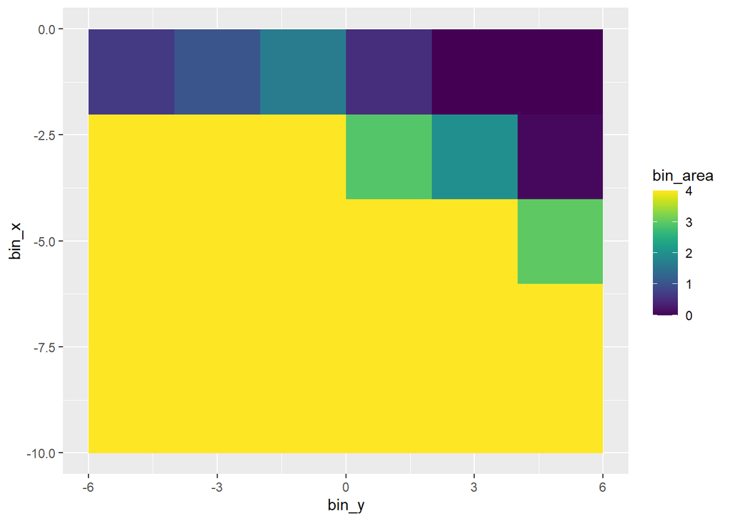

```r
print(bin_fun(file_vec[1],gameId_vec[1], 76)[[1]][[15]])
```

```r
print(bin_fun(file_vec[1],gameId_vec[1], 76)[[2]])
```

```
##      bin_id bin_area          gameId playId frameId relevant_frame
##   1:      1 3.721732 2020_04_DEN_NYJ     76      64              1
##   2:      2 4.000000 2020_04_DEN_NYJ     76      64              1
##   3:      3 4.000000 2020_04_DEN_NYJ     76      64              1
##   4:      4 4.000000 2020_04_DEN_NYJ     76      64              1
##   5:      5 4.000000 2020_04_DEN_NYJ     76      64              1
##  ---
## 656:     26 0.000000 2020_04_DEN_NYJ     76      85             22
## 657:     27 0.000000 2020_04_DEN_NYJ     76      85             22
## 658:     28 0.000000 2020_04_DEN_NYJ     76      85             22
## 659:     29 1.307736 2020_04_DEN_NYJ     76      85             22
## 660:     30 3.926750 2020_04_DEN_NYJ     76      85             22
```

The `ang_info_fun` function below is used to calculate the offense’s and the quarterback’s area in specific regions (ie, blindside and center). This function iterates through 360 angles of space around the quarterback per frame, and consequently takes a long time to run and produces data too large to be uploaded to GitHub, so we won’t provide an example of its output here.

```r
ang_info_fun <- function(file_vec, gameId_vec, playId, frameId){
  # week_games_df <- game_conv_fun(file_vec, gameId_vec)
  week_games_df$event[week_games_df$event == "Pass Attempt"] <- "pass_forward"
  week_games_df$event[week_games_df$event == "Snap"] <- "ball_snap"

  return_list <- list()
  area_info_game_list <- list()
  angle_game_list <- list()
  k <- 1
for (game_id in gameId_vec) {

  # print("game")
  # print(k)
  ind_game_df <- week_games_df[week_games_df$gameId==game_id,]
  ind_game_df <- merge(ind_game_df, game_play_df, by=c("gameId", "playId"))

  ball_df <- ind_game_df[ind_game_df$nflId==-1,]

  pass_forward_events <- (unique((ind_game_df[ind_game_df$play_type=="pass",])$playId))
  pass_forward_events <- pass_forward_events[!is.na(pass_forward_events)]


  pass_forward_info_df <- ind_game_df[ind_game_df$event=="pass_forward" & ind_game_df$playId %in% pass_forward_events,]
  pass_forward_events_df <- aggregate(frameId ~ playId, data = pass_forward_info_df , min)

  area_info_play_list <- list()
  angle_play_list <- list()
  j <- 1
  for (play_id in playId) {
    # print("play")
    # print(j)
    full_play_df <- ind_game_df[ind_game_df$playId==play_id,]
    line_set_frame <- min(unique(full_play_df[full_play_df$event=="Line Set",]$frameId))
    if (line_set_frame==Inf) {
      line_set_frame <- min(unique(na.omit(full_play_df[full_play_df$event=="ball_snap",]$frameId)))-1
      if (line_set_frame<1) {
        next
      }
    }
    initial_configuration_df <- full_play_df[full_play_df$frameId==line_set_frame & full_play_df$nflId==-1,]
    spec_frame_id <- pass_forward_events_df[pass_forward_events_df$playId==play_id,]$frameId

    ball_snap_frame <- min(unique(na.omit(full_play_df[full_play_df$event=="ball_snap",]$frameId)))
    pass_forward_frame <- min(unique(na.omit(full_play_df[full_play_df$event=="pass_forward",]$frameId)))

    if (ball_snap_frame==Inf | pass_forward_frame==Inf | line_set_frame==Inf) {
      next
    }

    ball_snap_configuration_df <- full_play_df[full_play_df$frameId==ball_snap_frame & full_play_df$nflId==-1,]

    time_of_pass_df <- full_play_df[full_play_df$frameId==spec_frame_id & full_play_df$nflId==-1,]

    qb_id_df <- full_play_df[full_play_df$nflId %in% qb_df$nflId & full_play_df$frameId==ball_snap_frame,]
    if (nrow(qb_id_df)>1) {
      qb_id_df$ball_dist <- sqrt(((ball_snap_configuration_df$x_coords-qb_id_df$x_coords)^2)+((ball_snap_configuration_df$y_coords-qb_id_df$y_coords)^2))
      qb_id_df <- qb_id_df[qb_id_df$ball_dist==min(qb_id_df$ball_dist),]
    }
    time_of_pass_qb_df <- full_play_df[full_play_df$frameId==spec_frame_id & full_play_df$nflId==qb_id_df$nflId,]

    qb_tot_df <- full_play_df[full_play_df$nflId %in% qb_id_df$nflId & full_play_df$frameId==spec_frame_id,]  #isolating the voronoi coordinates for the quarterback
    LOS_x <- initial_configuration_df$x_coords
    LOS_y <- initial_configuration_df$y_coords

    if (LOS_x>time_of_pass_qb_df$x_coords) {
      field_progress_indicator <- -1 ####make this value 1 or -1, calculate in play_id for loop. -1 means LOS_x>qb initial position, 1 means LOS_x<qb initial position

    } else {
      field_progress_indicator <- 1
    }

    norm_full_play_df <- full_play_df
    norm_full_play_df$x_coords <- (full_play_df$x_coords-LOS_x)*-1*field_progress_indicator
    norm_full_play_df$y_coords <- (full_play_df$y_coords-(160/6))*field_progress_indicator
    offensive_team <- unique(norm_full_play_df[norm_full_play_df$nflId %in% qb_df$nflId,]$team)

    time_of_pass_norm_df <- norm_full_play_df[norm_full_play_df$frameId==(spec_frame_id) & norm_full_play_df$nflId==-1,]
    time_before_pass_norm_df <- norm_full_play_df[norm_full_play_df$frameId==(spec_frame_id-1) & norm_full_play_df$nflId==-1,]

    pass_angle <- (atan((time_of_pass_norm_df$x_coords-time_before_pass_norm_df$x_coords)/(time_of_pass_norm_df$y_coords-time_before_pass_norm_df$y_coords)))*(180/pi)
    if (is.na(pass_angle)==TRUE) {
      pass_angle <- NA
    } else if (pass_angle<0) {
      pass_angle <- pass_angle+180
    }

    xbound1 <- -10
    ybound1 <- ((LOS_y-(160/6))*field_progress_indicator)+6
    ybound2 <- ((LOS_y-(160/6))*field_progress_indicator)-6

    play_frame_duration <- (pass_forward_frame-ball_snap_frame)+1

    norm_full_play_in_pocket_df <- norm_full_play_df[norm_full_play_df$nflId!=-1,] #omitting ball from dataframe
    norm_full_play_in_pocket_df <- norm_full_play_in_pocket_df[norm_full_play_in_pocket_df$frameId>=ball_snap_frame & norm_full_play_in_pocket_df$frameId<=pass_forward_frame,]
    norm_full_play_in_pocket_df <- norm_full_play_in_pocket_df[norm_full_play_in_pocket_df$y_coords<ybound1 & norm_full_play_in_pocket_df$y_coords>ybound2,]
    norm_full_play_in_pocket_df <- norm_full_play_in_pocket_df[rowSums(is.na(norm_full_play_in_pocket_df)) != ncol(norm_full_play_in_pocket_df), ]
    full_play_pocket_df <- norm_full_play_in_pocket_df[(norm_full_play_in_pocket_df$x_coords>xbound1 & norm_full_play_in_pocket_df$x_coords<0),]

    y_coord_adj <- (norm_full_play_df[norm_full_play_df$frameId==1 & norm_full_play_df$nflId==-1,]$y_coords)

    player_in_pocket_frame_count_df<- (aggregate(frameId ~ nflId, data = full_play_pocket_df , length))
    player_in_pocket_frame_count_df$freq <- player_in_pocket_frame_count_df$frameId/play_frame_duration
    adj_player_in_pocket_df <- player_in_pocket_frame_count_df[player_in_pocket_frame_count_df$freq>=0.5,]


    pocket_players_at_snap_df <- norm_full_play_df[norm_full_play_df$frameId==ball_snap_frame & norm_full_play_df$nflId %in% adj_player_in_pocket_df$nflId,]
    rel_pos_df <- merge(pocket_players_at_snap_df, pos_df, by="nflId")
    rel_pos_df <- data.frame(nflId=rel_pos_df$nflId, "PositionAbbr"=rel_pos_df$PositionAbbr)
    pocket_players_at_snap_df <- merge(rel_pos_df,pocket_players_at_snap_df, by="nflId", all=T)
    pocket_players_at_snap_df$PositionAbbr[is.na(pocket_players_at_snap_df$PositionAbbr)] <- "UN"
    oline_players_at_snap_df <- pocket_players_at_snap_df[pocket_players_at_snap_df$team==offensive_team & pocket_players_at_snap_df$PositionAbbr!="QB" & pocket_players_at_snap_df$PositionAbbr!="RB",]
    qb_at_snap_df <- pocket_players_at_snap_df[pocket_players_at_snap_df$PositionAbbr=="QB",]
    if (nrow(qb_at_snap_df)==0) {
      next
    }
    qb_in_pocket_df <- adj_player_in_pocket_df[adj_player_in_pocket_df$nflId==qb_at_snap_df$nflId[1],]
    if (qb_in_pocket_df$freq<1) {
      next
    }
```

```r
    oline_players_at_snap_df <- oline_players_at_snap_df[order(oline_players_at_snap_df$y_coords),]
    if (nrow(oline_players_at_snap_df)>0) {
      oline_players_at_snap_df$ordering <- 1:nrow(oline_players_at_snap_df)
    } else {
      oline_players_at_snap_df$ordering <- numeric(nrow(oline_players_at_snap_df))
    }
    oline_ordering_df <- data.frame(nflId=oline_players_at_snap_df$nflId, ordering=oline_players_at_snap_df$ordering)

    voronoi_x_list <- list()
    voronoi_y_list <- list()
    voronoi_nflId_list <- list()
    voronoi_frameid_list <- list()

    voronoi_area_vec <- rep(NA, times=length(ball_snap_frame:max(full_play_df$frameId)))
    rect <- data.frame(x=c(xbound1, 0, 0, xbound1, xbound1), y=c(ybound1, ybound1, ybound2, ybound2, ybound1))

    oline_ordering_wQB_df <- oline_ordering_df
    oline_ordering_wQB_df[nrow(oline_ordering_wQB_df)+1,] <- c(qb_at_snap_df$nflId, 0)

    area_info_frame_list <- list()
    angle_frame_list <- list()

    i <- 1
    for (frame_id in frameId) {
      # print("frame")
      # print(i)

      spec_frame_df <- norm_full_play_df[norm_full_play_df$frameId==frame_id,]
      frame_omit_ball_df <- spec_frame_df[spec_frame_df$nflId!=-1,] #omitting ball from dataframe
      spec_frame_wo_ball_df <- frame_omit_ball_df[frame_omit_ball_df$y_coords<ybound1 & frame_omit_ball_df$y_coords>ybound2,]
      spec_frame_wo_ball_df <- spec_frame_wo_ball_df[rowSums(is.na(spec_frame_wo_ball_df)) != ncol(spec_frame_wo_ball_df), ]

      spec_players_df <- spec_frame_df[spec_frame_df$nflId %in% adj_player_in_pocket_df$nflId,]
      spec_players_df <- (merge(spec_players_df, rel_pos_df, by="nflId", all=T))
      spec_players_df$PositionAbbr[is.na(spec_players_df$PositionAbbr)] <- "UN"

      player_team_df <- data.frame(nflId=spec_players_df$nflId, team=spec_players_df$team)

      off_players_df <- spec_players_df[spec_players_df$team==offensive_team,]
      def_players_df <- frame_omit_ball_df[frame_omit_ball_df$team!=offensive_team,]
      oline_df <- off_players_df[off_players_df$PositionAbbr!="QB" & off_players_df$PositionAbbr!="RB",]
      oline_wQB_df <- off_players_df[off_players_df$PositionAbbr!="RB",]
      oline_df <- merge(oline_df, oline_ordering_df, by="nflId")
      oline_wQB_df <- merge(oline_wQB_df, oline_ordering_wQB_df, by="nflId")
      qb_frame_df <- off_players_df[off_players_df$PositionAbbr=="QB",]

      if (nrow(oline_df)>0) {
        oline_df$relevant_frame <- (oline_df$frameId-ball_snap_frame)+1
        oline_df$players_on_line <- nrow(oline_df)

        oline_wQB_df$relevant_frame <- (oline_wQB_df$frameId-ball_snap_frame)+1
        oline_wQB_df$players_on_line <- nrow(oline_df)
      } else {
        oline_df$relevant_frame = numeric(nrow(oline_df))
        oline_df$players_on_line = numeric(nrow(oline_df))

        oline_wQB_df$relevant_frame = numeric(nrow(oline_wQB_df))
        oline_wQB_df$players_on_line = numeric(nrow(oline_wQB_df))
      }

      pocket_df <- spec_frame_wo_ball_df[(spec_frame_wo_ball_df$x_coords>xbound1 & spec_frame_wo_ball_df$x_coords<0),]

      def_players_df$PositionAbbr <- NULL
      off_vor_calc_df <- spec_frame_wo_ball_df[spec_frame_wo_ball_df$nflId %in% oline_wQB_df$nflId,]
      vor_calc_df <- rbind(off_vor_calc_df, def_players_df)
      vor_calc_df$duplicated <- duplicated(vor_calc_df[,3:4])
      vor_calc_df <- vor_calc_df[vor_calc_df$duplicated==FALSE,]
      vor_calc_df$duplicated <- NULL
      vor_calc_df <- as.data.frame(vor_calc_df)

      vor_spdf <- voronoi_polygon(data=vor_calc_df,x="x_coords",y="y_coords", outline=rect)
      vor_df <- fortify_voronoi(vor_spdf)
      mp_sf <- st_as_sf(vor_spdf)
      p_sf <- st_cast(mp_sf, "POLYGON")
      p_qb_sf <- p_sf[p_sf$nflId==qb_frame_df$nflId,]
      if (nrow(p_qb_sf)==0) {
        next
      }
      p_qb_sf_line <- p_sf[p_sf$team==offensive_team,]
      area <- st_area(p_qb_sf)
      area_line <- sum(st_area(p_qb_sf_line))

      area_info_df <- data.frame(nflId=p_qb_sf$nflId, qb_tot_area=area, line_tot_area=area_line)


      rect_qbf = data.frame(x=c(qb_frame_df$x_coords, 0, 0, qb_frame_df$x_coords, qb_frame_df$x_coords), y=c(ybound1, ybound1, ybound2, ybound2, ybound1))


      vor_spdf_qbf <- voronoi_polygon(data=vor_calc_df ,x="x_coords",y="y_coords", outline=rect_qbf)
      vor_df_qbf <- fortify_voronoi(vor_spdf_qbf)
      mp_sf_qbf <- st_as_sf(vor_spdf_qbf)
      p_sf_qbf <- st_cast(mp_sf_qbf, "POLYGON")
      p_sf_qbf_pres <- p_sf_qbf
      p_sf_qbf <- p_sf_qbf[p_sf_qbf$nflId==qb_frame_df$nflId,]
      p_sf_qbf_line <- p_sf_qbf_pres[p_sf_qbf_pres$team==offensive_team,]
      area_qbf <- st_area(p_sf_qbf)
      area_qbf_line <- sum(st_area(p_sf_qbf_line))


      area_info_df$qb_front_area <- area_qbf
      area_info_df$line_front_area <- area_qbf_line
      area_info_df$frameId <- frame_id
      area_info_df$playId <- play_id
      area_info_df$gameId <- game_id
      area_info_df$relevant_frame <- (area_info_df$frameId-ball_snap_frame)+1

      angle_info_list <- list()
      a <- 1
      for (angle_deg in c(1:360)) {
        angle <- angle_deg*(pi/180)
        m <- tan(angle)

        m_prev <- tan(angle-(pi/180))


        ybound1_rise <- ((ybound1-qb_frame_df$y_coords)*m)+qb_frame_df$x_coords
        ybound2_rise <- ((ybound2-qb_frame_df$y_coords)*m)+qb_frame_df$x_coords

        ybound1_rise_prev <- ((ybound1-qb_frame_df$y_coords)*m_prev)+qb_frame_df$x_coords
        ybound2_rise_prev <- ((ybound2-qb_frame_df$y_coords)*m_prev)+qb_frame_df$x_coords

        if (ybound1_rise>0) {
          x1_end <- 0
          y1_end <- ((-qb_frame_df$x_coords)/m)+qb_frame_df$y_coords
        } else if (ybound1_rise<(-10)) {
          x1_end <- -10
          y1_end <- ((-10-qb_frame_df$x_coords)/m)+qb_frame_df$y_coords
        } else {
          x1_end <- ybound1_rise
          y1_end <- ybound1
        }

        if (ybound1_rise_prev>0) {
          x1_end_prev <- 0
          y1_end_prev <- ((-qb_frame_df$x_coords)/m_prev)+qb_frame_df$y_coords
        } else if (ybound1_rise_prev<(-10)) {
          x1_end_prev <- -10
          y1_end_prev <- ((-10-qb_frame_df$x_coords)/m_prev)+qb_frame_df$y_coords
        } else {
          x1_end_prev <- ybound1_rise_prev
          y1_end_prev <- ybound1
        }
```

```r
        if (ybound2_rise>0) {
          x2_end <- 0
          y2_end <- ((-qb_frame_df$x_coords)/m)+qb_frame_df$y_coords
        } else if (ybound2_rise<(-10)) {
          x2_end <- -10
          y2_end <- ((-10-qb_frame_df$x_coords)/m)+qb_frame_df$y_coords
        } else {
          x2_end <- ybound2_rise
          y2_end <- ybound2
        }

        if (ybound2_rise_prev>0) {
          x2_end_prev <- 0
          y2_end_prev <- ((-qb_frame_df$x_coords)/m_prev)+qb_frame_df$y_coords
        } else if (ybound2_rise_prev<(-10)) {
          x2_end_prev <- -10
          y2_end_prev <- ((-10-qb_frame_df$x_coords)/m_prev)+qb_frame_df$y_coords
        } else {
          x2_end_prev <- ybound2_rise_prev
          y2_end_prev <- ybound2
        }

        if (m>=0) {
          corner1_x <- -10
          corner1_y <- ybound2

          corner2_x <- 0
          corner2_y <- ybound2
        } else {
          corner1_x <- 0
          corner1_y <- ybound1

          corner2_x <- -10
          corner2_y <- ybound1
        }

        if (m_prev>=0) {
          corner1_x_prev <- -10
          corner1_y_prev <- ybound2

          corner2_x_prev <- 0
          corner2_y_prev <- ybound2
        } else {
          corner1_x_prev <- 0
          corner1_y_prev <- ybound1

          corner2_x_prev <- -10
          corner2_y_prev <- ybound1
        }


        if (m>=0 & ybound1_rise<0 & ybound2_rise>-10) {
          corner2_x <- 0
          corner2_y <- ybound1

          corner1_x <- 0
          corner1_y <- ybound2
        }

        if (m>=0 & ybound1_rise_prev<0 & ybound2_rise_prev>-10) {
          corner2_x_prev <- 0
          corner2_y_prev <- ybound1

          corner1_x_prev <- 0
          corner1_y_prev <- ybound2
        }


        if (angle_deg<=(90)) {
          rect_qbdirf <- data.frame(x=c(qb_frame_df$x_coords,x1_end,x1_end_prev,qb_frame_df$x_coords),
                                    y=c(qb_frame_df$y_coords,y1_end,y1_end_prev,qb_frame_df$y_coords))
        } else if (angle_deg==91) {
          rect_qbdirf <- data.frame(x=c(qb_frame_df$x_coords,x2_end,x1_end_prev,qb_frame_df$x_coords),
                                    y=c(qb_frame_df$y_coords,y2_end,y1_end_prev,qb_frame_df$y_coords))
        }else if (angle_deg <=(180) & angle_deg>90) {
          rect_qbdirf <- data.frame(x=c(qb_frame_df$x_coords,x2_end,x2_end_prev,qb_frame_df$x_coords),
                                    y=c(qb_frame_df$y_coords,y2_end,y2_end_prev,qb_frame_df$y_coords))
        } else if (angle_deg <=(270) & angle_deg>180) {
          rect_qbdirf <- data.frame(x=c(qb_frame_df$x_coords,x2_end_prev,x2_end,qb_frame_df$x_coords),
                                    y=c(qb_frame_df$y_coords,y2_end_prev,y2_end,qb_frame_df$y_coords))
        } else if (angle_deg == 271) {
          rect_qbdirf <- data.frame(x=c(qb_frame_df$x_coords,x2_end_prev,x1_end,qb_frame_df$x_coords),
                                    y=c(qb_frame_df$y_coords,y2_end_prev,y1_end,qb_frame_df$y_coords))
        } else if (angle_deg <=(360) & angle_deg>271) {
          rect_qbdirf <- data.frame(x=c(qb_frame_df$x_coords,x1_end_prev,x1_end,qb_frame_df$x_coords),
                                    y=c(qb_frame_df$y_coords,y1_end_prev,y1_end,qb_frame_df$y_coords))
        }


        vor_spdf_qbdirf <- voronoi_polygon(data=vor_calc_df ,x="x_coords",y="y_coords", outline=rect_qbdirf)
        vor_df_qbdirf <- fortify_voronoi(vor_spdf_qbdirf)
        mp_sf_qbdirf <- st_as_sf(vor_spdf_qbdirf)
        p_sf_qbdirf <- st_cast(mp_sf_qbdirf, "POLYGON")
        p_sf_qbdirf_pres <- p_sf_qbdirf
        p_sf_qbdirf <- p_sf_qbdirf[p_sf_qbdirf$nflId==qb_frame_df$nflId,]
        p_sf_qbdirf_line <- p_sf_qbdirf_pres[p_sf_qbdirf_pres$team==offensive_team,]
        area_qbdirf <- st_area(p_sf_qbdirf)
        area_qbdirf_line <- sum(st_area(p_sf_qbdirf_line))

        angle_area_info_df <- data.frame(gameId=game_id, playId=play_id, frameId=frame_id, angle=angle_deg, qb_front_angle_area=area_qbdirf, line_front_angle_area=area_qbdirf_line)
        angle_info_list[[a]] <- angle_area_info_df
        a <- a+1
        # print(a)
      }


      angle_info_frame <- rbindlist(angle_info_list)

      angle_frame_list[[i]] <- angle_info_frame
      area_info_frame_list[[i]] <- area_info_df

      i <- i+1
    }
    angle_play_list[[j]] <- rbindlist(angle_frame_list)
    area_info_play_list[[j]] <- rbindlist(area_info_frame_list)
    j <- j+1
  }
  angle_game_list[[k]] <- rbindlist(angle_play_list)
  area_info_game_list[[k]] <- rbindlist(area_info_play_list)
  k <- k+1
}

  return_list[[1]] <- rbindlist(angle_game_list)
  return_list[[2]] <- rbindlist(area_info_game_list)
  return(return_list)
}
```

The `surv_fun` function below performs a survival analysis in the form of a Kaplan-Meier estimator on the data gleaned above. The code commented out in this function is the code that retrieves the survival data/graphs for the blindside/center. This analysis is dependent on data that takes too long to process for this example and likewise is too large to upload to GitHub. The necessary data for this analysis can be retrieved using the `angle_info_fun` function.

```r
surv_fun <- function(summary_info_df, angle_info_df, play_info_df,bin_info_df){
total_plays <- nrow(aggregate(frameId~gameId+playId, summary_info_df, length))
plot_list <- list()
survive_df_list <- list()
return_list <- list()

# analysis_df <- merge(angle_info_df, summary_info_df)
# analysis_df$nflId <- NULL
# play_info_df$nflId <- NULL
# det_analysis_df <- merge(play_info_df, analysis_df, by=c("gameId", "playId"))
# det_analysis_df <- det_analysis_df[order(det_analysis_df$gameId,det_analysis_df$playId,det_analysis_df$relevant_frame,det_analysis_df$angle),]
surv_analysis_df <- merge(summary_info_df, play_info_df, by=c("gameId", "playId"))
surv_analysis_df <- surv_analysis_df[order(surv_analysis_df$gameId, surv_analysis_df$playId, surv_analysis_df$relevant_frame),]
surv_analysis_atpass_df <- surv_analysis_df[surv_analysis_df$relevant_frame==surv_analysis_df$pass_forward_relevant_frame,]
at_pass_info_df <- data.frame(gameId=surv_analysis_atpass_df$gameId, playId=surv_analysis_atpass_df$playId,
                              relevant_frame=surv_analysis_atpass_df$relevant_frame, pass_forward_relevant_frame=surv_analysis_atpass_df$pass_forward_relevant_frame)
row.names(surv_analysis_atpass_df) <- NULL

surv_analysis_df$line_area_survive <- 1
surv_analysis_df$line_area_survive[surv_analysis_df$line_tot_area<65.214] <- 0 #This sets the failure threshold for total offensive line area. The other thresholds are below.

surv_analysis_df$qb_area_survive <- 1
surv_analysis_df$qb_area_survive[surv_analysis_df$qb_tot_area<15.4882] <- 0

bin_info_df$bin_area_survive <- 1
bin_info_df$bin_area_survive[bin_info_df$bin_area<1.51018] <- 0

# line_blindside_analysis_df <- det_analysis_df[det_analysis_df$angle>150 & det_analysis_df$angle<300,]
# line_blindside_analysis_agg<- aggregate(line_front_angle_area~gameId+playId+relevant_frame, line_blindside_analysis_df, sum)
# line_blindside_analysis_agg$angle_area_survive <- 1
# line_blindside_analysis_agg$angle_area_survive[line_blindside_analysis_agg$line_front_angle_area<14.52] <- 0
#
# qb_blindside_analysis_agg<- aggregate(qb_front_angle_area~gameId+playId+relevant_frame, line_blindside_analysis_df, sum)
# qb_blindside_analysis_agg$angle_area_survive <- 1
# qb_blindside_analysis_agg$angle_area_survive[qb_blindside_analysis_agg$qb_front_angle_area<6.373] <- 0
#
# line_center_analysis_df <- det_analysis_df[det_analysis_df$angle>60 & det_analysis_df$angle<120,]
# line_center_analysis_agg<- aggregate(line_front_angle_area~gameId+playId+relevant_frame, line_center_analysis_df, sum)
# line_center_analysis_agg$angle_area_survive <- 1
# line_center_analysis_agg$angle_area_survive[line_center_analysis_agg$line_front_angle_area<11.14] <- 0
#
# qb_center_analysis_agg<- aggregate(qb_front_angle_area~gameId+playId+relevant_frame, line_center_analysis_df, sum)
# qb_center_analysis_agg$angle_area_survive <- 1
# qb_center_analysis_agg$angle_area_survive[qb_center_analysis_agg$qb_front_angle_area<1.153] <- 0

surv_game_list <- list()
surv_game_list_unc <- list()
surv_game_bin_list <- list()
m <- 1
for (game_id in unique(surv_analysis_df$gameId)) {
  ind_game_df <- surv_analysis_df[surv_analysis_df$gameId==game_id,]
  ind_game_bin_df <- bin_info_df[bin_info_df$gameId==game_id,]
  # ind_game_line_blindside_df <- line_blindside_analysis_agg[line_blindside_analysis_agg$gameId==game_id,]
  # ind_game_qb_blindside_df <- qb_blindside_analysis_agg[qb_blindside_analysis_agg$gameId==game_id,]
  # ind_game_line_center_df <- line_center_analysis_agg[line_center_analysis_agg$gameId==game_id,]
  # ind_game_qb_center_df <- qb_center_analysis_agg[qb_center_analysis_agg$gameId==game_id,]
  #
  frame_obs <- 35

  surv_play_list <- list()
  surv_play_list_unc <- list()
  surv_bin_play_list <- list()
  j <- 1
  for (play_id in unique(ind_game_df$playId)) {
    ind_play_df <- ind_game_df[ind_game_df$playId==play_id,]
    ind_play_bin_df <- ind_game_bin_df[ind_game_bin_df$playId==play_id,]
    # ind_play_line_blindside_df <- ind_game_line_blindside_df[ind_game_line_blindside_df$playId==play_id,]
    # ind_play_qb_blindside_df <- ind_game_qb_blindside_df[ind_game_qb_blindside_df$playId==play_id,]
    # ind_play_line_center_df <- ind_game_line_center_df[ind_game_line_center_df$playId==play_id,]
    # ind_play_qb_center_df <- ind_game_qb_center_df[ind_game_qb_center_df$playId==play_id,]

    line_survive_play_agg <- aggregate(line_area_survive~relevant_frame, ind_play_df, mean)
    qb_survive_play_agg <- aggregate(qb_area_survive~relevant_frame, ind_play_df, mean)
    # line_blindside_survive_play_agg <- aggregate(angle_area_survive~relevant_frame, ind_play_line_blindside_df, mean)
    # qb_blindside_survive_play_agg <- aggregate(angle_area_survive~relevant_frame, ind_play_qb_blindside_df, mean)
    # line_center_survive_play_agg <- aggregate(angle_area_survive~relevant_frame, ind_play_line_center_df, mean)
    # qb_center_survive_play_agg <- aggregate(angle_area_survive~relevant_frame, ind_play_qb_center_df, mean)

    fail_frame <- min(line_survive_play_agg[line_survive_play_agg$line_area_survive==0,]$relevant_frame)
    line_survive_play_agg$failure <- FALSE
    line_survive_play_agg$failure[line_survive_play_agg$relevant_frame==fail_frame] <- TRUE
    line_survive_play_agg$censored <- 1
    if (fail_frame==Inf) {
      line_survive_play_agg$failure[line_survive_play_agg$relevant_frame==max(line_survive_play_agg$relevant_frame)] <- TRUE
      line_survive_play_agg$censored[line_survive_play_agg$relevant_frame==max(line_survive_play_agg$relevant_frame)] <- 0
      fail_frame <- max(line_survive_play_agg$relevant_frame)+1
    }
    line_survive_play_agg$line_area_survive[line_survive_play_agg$relevant_frame>=fail_frame] <- 0

    qb_fail_frame <- min(qb_survive_play_agg[qb_survive_play_agg$qb_area_survive==0,]$relevant_frame)
    qb_survive_play_agg$failure <- FALSE
    qb_survive_play_agg$failure[qb_survive_play_agg$relevant_frame==qb_fail_frame] <- TRUE
    qb_survive_play_agg$censored <- 1
    if (qb_fail_frame==Inf) {
      qb_survive_play_agg$failure[qb_survive_play_agg$relevant_frame==max(qb_survive_play_agg$relevant_frame)] <- TRUE
      qb_survive_play_agg$censored[qb_survive_play_agg$relevant_frame==max(qb_survive_play_agg$relevant_frame)] <- 0
      qb_fail_frame <- max(qb_survive_play_agg$relevant_frame)+1
    }
    qb_survive_play_agg$qb_area_survive[qb_survive_play_agg$relevant_frame>=qb_fail_frame] <- 0
```

```r
    # blindside_fail_frame <- min(line_blindside_survive_play_agg[line_blindside_survive_play_agg$angle_area_survive==0,]$relevant_frame)
    # line_blindside_survive_play_agg$failure <- FALSE
    # line_blindside_survive_play_agg$failure[line_blindside_survive_play_agg$relevant_frame==blindside_fail_frame] <- TRUE
    # line_blindside_survive_play_agg$censored <- 1
    # if (blindside_fail_frame==Inf) {
    #   line_blindside_survive_play_agg$failure[line_blindside_survive_play_agg$relevant_frame==max(line_blindside_survive_play_agg$relevant_frame)] <- TRUE
    #   line_blindside_survive_play_agg$censored[line_blindside_survive_play_agg$relevant_frame==max(line_blindside_survive_play_agg$relevant_frame)] <- 0
    #   blindside_fail_frame <- max(line_blindside_survive_play_agg$relevant_frame)+1
    # }
    # line_blindside_survive_play_agg$angle_area_survive[line_blindside_survive_play_agg$relevant_frame>=blindside_fail_frame] <- 0
    #
    # qb_blindside_fail_frame <- min(qb_blindside_survive_play_agg[qb_blindside_survive_play_agg$angle_area_survive==0,]$relevant_frame)
    # qb_blindside_survive_play_agg$failure <- FALSE
    # qb_blindside_survive_play_agg$failure[qb_blindside_survive_play_agg$relevant_frame==qb_blindside_fail_frame] <- TRUE
    # qb_blindside_survive_play_agg$censored <- 1
    # if (qb_blindside_fail_frame==Inf) {
    #   qb_blindside_survive_play_agg$failure[qb_blindside_survive_play_agg$relevant_frame==max(qb_blindside_survive_play_agg$relevant_frame)] <- TRUE
    #   qb_blindside_survive_play_agg$censored[qb_blindside_survive_play_agg$relevant_frame==max(qb_blindside_survive_play_agg$relevant_frame)] <- 0
    #   qb_blindside_fail_frame <- max(qb_blindside_survive_play_agg$relevant_frame)+1
    # }
    # qb_blindside_survive_play_agg$angle_area_survive[qb_blindside_survive_play_agg$relevant_frame>=qb_blindside_fail_frame] <- 0
    #
    # center_fail_frame <- min(line_center_survive_play_agg[line_center_survive_play_agg$angle_area_survive==0,]$relevant_frame)
    # line_center_survive_play_agg$failure <- FALSE
    # line_center_survive_play_agg$failure[line_center_survive_play_agg$relevant_frame==center_fail_frame] <- TRUE
    # line_center_survive_play_agg$censored <- 1
    # if (center_fail_frame==Inf) {
    #   line_center_survive_play_agg$failure[line_center_survive_play_agg$relevant_frame==max(line_center_survive_play_agg$relevant_frame)] <- TRUE
    #   line_center_survive_play_agg$censored[line_center_survive_play_agg$relevant_frame==max(line_center_survive_play_agg$relevant_frame)] <- 0
    #   center_fail_frame <- max(line_center_survive_play_agg$relevant_frame)+1
    # }
    # line_center_survive_play_agg$angle_area_survive[line_center_survive_play_agg$relevant_frame>=center_fail_frame] <- 0
    #
    #
    # qb_center_fail_frame <- min(qb_center_survive_play_agg[qb_center_survive_play_agg$angle_area_survive==0,]$relevant_frame)
    # qb_center_survive_play_agg$failure <- FALSE
    # qb_center_survive_play_agg$failure[qb_center_survive_play_agg$relevant_frame==qb_center_fail_frame] <- TRUE
    # qb_center_survive_play_agg$censored <- 1
    # if (qb_center_fail_frame==Inf) {
    #   qb_center_survive_play_agg$failure[qb_center_survive_play_agg$relevant_frame==max(qb_center_survive_play_agg$relevant_frame)] <- TRUE
    #   qb_center_survive_play_agg$censored[qb_center_survive_play_agg$relevant_frame==max(qb_center_survive_play_agg$relevant_frame)] <- 0
    #   qb_center_fail_frame <- max(qb_center_survive_play_agg$relevant_frame)+1
    # }
    # qb_center_survive_play_agg$angle_area_survive[qb_center_survive_play_agg$relevant_frame>=qb_center_fail_frame] <- 0
    #

    names(line_survive_play_agg)[names(line_survive_play_agg) == 'line_area_survive'] <- 'Survive'
    names(qb_survive_play_agg)[names(qb_survive_play_agg) == 'qb_area_survive'] <- 'Survive'
    # names(line_blindside_survive_play_agg)[names(line_blindside_survive_play_agg) == 'angle_area_survive'] <- 'Survive'
    # names(qb_blindside_survive_play_agg)[names(qb_blindside_survive_play_agg) == 'angle_area_survive'] <- 'Survive'
    # names(line_center_survive_play_agg)[names(line_center_survive_play_agg) == 'angle_area_survive'] <- 'Survive'
    # names(qb_center_survive_play_agg)[names(qb_center_survive_play_agg) == 'angle_area_survive'] <- 'Survive'
    line_survive_play_agg$survive_id <- "line_total"
    qb_survive_play_agg$survive_id <- "qb_total"
    # line_blindside_survive_play_agg$survive_id <- "line_blindside"
    # qb_blindside_survive_play_agg$survive_id <- "qb_blindside"
    # line_center_survive_play_agg$survive_id <- "line_center"
    # qb_center_survive_play_agg$survive_id <- "qb_center"
    #
    survive_play_agg <- bind_rows(qb_survive_play_agg, line_survive_play_agg
                                  # line_blindside_survive_play_agg, qb_blindside_survive_play_agg, line_center_survive_play_agg, qb_center_survive_play_agg
                                  )

    survive_play_agg_unc <- survive_play_agg
    survive_play_agg <- survive_play_agg[survive_play_agg$failure==TRUE,]

    surv_play_list[[j]] <- survive_play_agg
    surv_play_list_unc[[j]] <- survive_play_agg_unc

    surv_bin_list <- list()
    s <- 1
    for (bin_id in unique(ind_play_bin_df$bin_id)) {
      ind_bin_df <- ind_play_bin_df[ind_play_bin_df$bin_id==bin_id,]
      bin_survive_agg_df <- aggregate(bin_area_survive~relevant_frame, ind_bin_df, mean)
      bin_fail_frame <- min(bin_survive_agg_df[bin_survive_agg_df$bin_area_survive==0,]$relevant_frame)
      bin_survive_agg_df$failure <- FALSE
      bin_survive_agg_df$failure[bin_survive_agg_df$relevant_frame==bin_fail_frame] <- TRUE
      bin_survive_agg_df$censored <- 1
      if (bin_fail_frame==Inf) {
        bin_survive_agg_df$failure[bin_survive_agg_df$relevant_frame==max(bin_survive_agg_df$relevant_frame)] <- TRUE
        bin_survive_agg_df$censored[bin_survive_agg_df$relevant_frame==max(bin_survive_agg_df$relevant_frame)] <- 0
        bin_fail_frame <- max(bin_survive_agg_df$relevant_frame)+1
      }
      bin_survive_agg_df$bin_area_survive[bin_survive_agg_df$relevant_frame>=bin_fail_frame] <- 0
```

```r
      bin_survive_agg_df$bin_id <- bin_id
      surv_bin_list[[s]] <- bin_survive_agg_df
      s <- s+1


    }

    surv_bin_play_list[[j]] <- rbindlist(surv_bin_list)
    j <- j+1
  }
  surv_game_list[[m]] <- rbindlist(surv_play_list)
  surv_game_list_unc[[m]] <- rbindlist(surv_play_list_unc)
  surv_game_bin_list[[m]] <- rbindlist(surv_bin_play_list)
  m <- m+1
}

surv_corr_df <- rbindlist(surv_game_list)
bin_surv_corr_df <- rbindlist(surv_game_bin_list)
surv_corr_unc_df <- rbindlist(surv_game_list_unc)


survive_agg <- (na.omit(surv_corr_unc_df[surv_corr_unc_df$failure==TRUE,]))
survive_agg<- survive_agg[survive_agg$relevant_frame<36,]
survive_agg <- survive_agg[order(survive_agg$survive_id, survive_agg$relevant_frame),]
# survive_agg <- survive_agg[survive_agg$survive_id=="line_total",]
survive_length_agg <- aggregate(failure~survive_id+relevant_frame, survive_agg, length)
survive_length_agg <- survive_length_agg[order(survive_length_agg$survive_id, survive_length_agg$relevant_frame),]
names(survive_length_agg)[names(survive_length_agg) == "failure"] <- "failure_length"
surv_agg <- merge(survive_length_agg, data.frame(relevant_frame=rep(c(1:35),length(unique(survive_agg$survive_id))),survive_id=sort(rep(c(unique(survive_agg$survive_id)),35))), by=c("relevant_frame","survive_id"), all=T)
surv_agg <- surv_agg[order(surv_agg$survive_id, surv_agg$relevant_frame),]
surv_agg$failure_length[is.na(surv_agg$failure_length)] <- 0
id_length_df <- aggregate(failure_length~survive_id, surv_agg, sum)
id_length_df$fl_adj <- cumsum(c(0, id_length_df$failure_length[-nrow(id_length_df)]))
id_length_df$failure_length <- NULL
surv_agg <- merge(surv_agg, id_length_df, by=c("survive_id"))
surv_agg$survival_rate <- 1-((cumsum(surv_agg$failure_length)-surv_agg$fl_adj)/total_plays)

surv_agg$hazard<- c(  c(1,((surv_agg[surv_agg$survive_id==sort(unique(surv_agg$survive_id))[1],]$survival_rate[-1]/surv_agg[surv_agg$survive_id==sort(unique(surv_agg$survive_id))[1],]$survival_rate))[-35]),
                      c(1,((surv_agg[surv_agg$survive_id==sort(unique(surv_agg$survive_id))[2],]$survival_rate[-1]/surv_agg[surv_agg$survive_id==sort(unique(surv_agg$survive_id))[2],]$survival_rate))[-35])
                      # c(1,((surv_agg[surv_agg$survive_id==sort(unique(surv_agg$survive_id))[3],]$survival_rate[-1]/surv_agg[surv_agg$survive_id==sort(unique(surv_agg$survive_id))[3],]$survival_rate))[-35]),
                      # c(1,((surv_agg[surv_agg$survive_id==sort(unique(surv_agg$survive_id))[4],]$survival_rate[-1]/surv_agg[surv_agg$survive_id==sort(unique(surv_agg$survive_id))[4],]$survival_rate))[-35]),
                      # c(1,((surv_agg[surv_agg$survive_id==sort(unique(surv_agg$survive_id))[5],]$survival_rate[-1]/surv_agg[surv_agg$survive_id==sort(unique(surv_agg$survive_id))[5],]$survival_rate))[-35]),
                      # c(1,((surv_agg[surv_agg$survive_id==sort(unique(surv_agg$survive_id))[6],]$survival_rate[-1]/surv_agg[surv_agg$survive_id==sort(unique(surv_agg$survive_id))[6],]$survival_rate))[-35])
                      )

surv_agg <- surv_agg[order(surv_agg$survive_id, surv_agg$relevant_frame),]
surv_agg$survive_id[surv_agg$survive_id=="line_total"] <- "Offensive Voronoi Space"
surv_agg$survive_id[surv_agg$survive_id=="qb_total"] <- "QB Voronoi Space"
# surv_agg$survive_id[surv_agg$survive_id=="line_blindside"] <- "Offensive Voronoi Space, Blindside"
# surv_agg$survive_id[surv_agg$survive_id=="qb_blindside"] <- "QB Voronoi Space, Blindside"
# surv_agg$survive_id[surv_agg$survive_id=="line_center"] <- "Offensive Voronoi Space, Center"
# surv_agg$survive_id[surv_agg$survive_id=="qb_center"] <- "QB Voronoi Space, Center"

survive_df_list[[1]] <- surv_agg

stand_features_df <- surv_agg[surv_agg$survive_id=="Offensive Voronoi Space" | surv_agg$survive_id=="QB Voronoi Space",]
surv_p_stand <- ggplot(stand_features_df, aes(x=relevant_frame, y=survival_rate, group=survive_id, color=survive_id))+geom_smooth(method='loess', span=0.4, se=FALSE, size=1.5,size=4)+
  geom_vline(xintercept=22, size=1, linetype="dashed")+geom_vline(xintercept=35, size=1, linetype="dashed", color="red")+
  annotate("text", x=18.6, y=0, label= "Median Time to Throw", size=3)+
  annotate("text", x=33, y=0, label= "Censor Time", size=3)+xlab("Frames After Snap")+
  ylab("Survival Probability")+ labs(color='Survival ID')+ylim(0,1)+ theme_grey(base_size = 9)
stand_features_haz_df <- na.omit(surv_agg[surv_agg$survive_id=="Offensive Voronoi Space" | surv_agg$survive_id=="QB Voronoi Space",])
haz_p_stand <- ggplot(stand_features_haz_df, aes(x=relevant_frame, y=hazard, group=survive_id, color=survive_id))+geom_smooth(method='loess', span=0.4, se=FALSE, size=1.5,size=4)+
  # xlim(0,30)+
  geom_vline(xintercept=22, size=1, linetype="dashed")+geom_vline(xintercept=35, size=1, linetype="dashed", color="red")+
  annotate("text", x=18.6, y=0.8, label= "Median Time to Throw", size=3)+
  annotate("text", x=33, y=0.8, label= "Censor Time", size=3)+xlab("Frames After Snap")+
  ylab("Hazard Probability")+ labs(color='Survival ID')+ylim(0.8,1)+ theme_grey(base_size = 9)

stand_figure <- ggarrange(surv_p_stand, haz_p_stand, common.legend = TRUE, legend = "bottom")

stand_figure <-annotate_figure(stand_figure,
                               bottom = text_grob("*Note difference in scales of y-axis", color = "black",
                                                  hjust = 1.1, x = 1, face = "italic", size = 5)
)

plot_list[[1]] <- stand_figure

###this is the code to produce and compare the survival/hazard plots of the blindside and center voronoi space
# spec_features_df <- surv_agg[surv_agg$survive_id!="Offensive Voronoi Space" & surv_agg$survive_id!="QB Voronoi Space",]
# surv_p_spec <- ggplot(spec_features_df, aes(x=relevant_frame, y=survival_rate, group=survive_id, color=survive_id))+geom_smooth(method='loess', span=0.4, se=FALSE, size=1.5,size=4)+
#   # xlim(0,30)+
#   geom_vline(xintercept=22, size=1, linetype="dashed")+geom_vline(xintercept=35, size=1, linetype="dashed", color="red")+
#   annotate("text", x=18.6, y=0.9, label= "Median Time to Throw", size=3)+
#   annotate("text", x=33, y=0.9, label= "Censor Time", size=3)+xlab("Frames After Snap")+
#   ylab("Survival Probability")+ labs(color='Survival ID')+ylim(0,1)+theme_grey(base_size = 9)
# #
# #   spec_fatures_haz_df <- na.omit(spec_features_df)
# haz_p_spec <- ggplot(spec_features_df, aes(x=relevant_frame, y=hazard, group=survive_id, color=survive_id))+geom_smooth(method='loess', span=0.4, se=FALSE, size=1.5,size=4)+
#   geom_vline(xintercept=22, size=1, linetype="dashed")+geom_vline(xintercept=35, size=1, linetype="dashed", color="red")+
#   annotate("text", x=18.6, y=0.6, label= "Median Time to Throw", size=3)+
#   annotate("text", x=33, y=0.6, label= "Censor Time", size=3)+xlab("Frames After Snap")+
#   ylab("Hazard Probability")+ labs(color='Survival ID')+ylim(0.6,1)+theme_grey(base_size = 9)
#
# spec_figure <- ggarrange(surv_p_spec, haz_p_spec, common.legend = TRUE, legend = "bottom")
#
# spec_figure <- annotate_figure(spec_figure,
#                                bottom = text_grob("*Note difference in scales of y-axis", color = "black",
#                                                   hjust = 1.1, x = 1, face = "italic", size = 5)
# )
# plot_list[[2]] <- spec_figure
# lg_rank_df <- na.omit(surv_corr_df)
# row.names(lg_rank_df) <- NULL
# lg_rank_df <- lg_rank_df[lg_rank_df$survive_i=="line_blindside"| lg_rank_df$survive_id=="line_center",]
# attach(lg_rank_df)
# lg_rank <- survdiff(Surv(relevant_frame, censored)~survive_id)
# detach(lg_rank_df)
```

```r
bin_surv_corr_df <- rbindlist(surv_game_bin_list)
bin_survive_agg <- (na.omit(bin_surv_corr_df[bin_surv_corr_df$failure==TRUE,]))
bin_survive_agg<- bin_survive_agg[bin_survive_agg$relevant_frame<36,]
bin_survive_agg <- bin_survive_agg[order(bin_survive_agg$bin_id, bin_survive_agg$relevant_frame),]
bin_survive_length_agg <- aggregate(failure~bin_id+relevant_frame, bin_survive_agg, length)
bin_survive_length_agg <- bin_survive_length_agg[order(bin_survive_length_agg$bin_id, bin_survive_length_agg$relevant_frame),]
names(bin_survive_length_agg)[names(bin_survive_length_agg) == "failure"] <- "failure_length"

bin_surv_agg <- merge(bin_survive_length_agg, data.frame(relevant_frame=rep(c(1:35),length(unique(bin_survive_agg$bin_id))),bin_id=sort(rep(c(unique(bin_survive_agg$bin_id)),35))), by=c("relevant_frame","bin_id"), all=T)
bin_surv_agg <- bin_surv_agg[order(bin_surv_agg$bin_id, bin_surv_agg$relevant_frame),]
bin_surv_agg$failure_length[is.na(bin_surv_agg$failure_length)] <- 0
bin_id_length_df <- aggregate(failure_length~bin_id, bin_surv_agg, sum)
bin_id_length_df$fl_adj <- cumsum(c(0, bin_id_length_df$failure_length[-nrow(bin_id_length_df)]))
bin_id_length_df$failure_length <- NULL
bin_surv_agg <- merge(bin_surv_agg, bin_id_length_df, by=c("bin_id"))
bin_surv_agg$survival_rate <- 1-((cumsum(bin_surv_agg$failure_length)-bin_surv_agg$fl_adj)/total_plays)

survive_df_list[[2]] <- bin_surv_agg

###Bin Survival/Hazard Plot Production and Comparison
n <- 1
bin_plot_list <- list()
for (n in c(1:5)) {
  grp_bin_survive_agg <- bin_surv_agg[bin_surv_agg$bin_id==n| bin_surv_agg$bin_id==n+5| bin_surv_agg$bin_id==n+10| bin_surv_agg$bin_id==n+15| bin_surv_agg$bin_id==n+20| bin_surv_agg$bin_id==n+25,]
  bin_p <- ggplot(grp_bin_survive_agg, aes(x=relevant_frame, y=survival_rate, group=factor(bin_id), color=factor(bin_id)))+
    geom_smooth(method='loess', span=0.4, se=FALSE, size=1.5,size=4)+
    geom_vline(xintercept=22, size=1, linetype="dashed")+
    geom_vline(xintercept=35, size=1, linetype="dashed", color="red")+
    xlab("Frames After Snap")+
    ylab("Survival Probability")+ labs(color='bin_id')+ylim(0,1)+xlab("")+ylab("")
  bin_plot_list[[n]] <- bin_p
  n <- n+1
}
bin_figure <- ggarrange(bin_plot_list[[1]],bin_plot_list[[2]],bin_plot_list[[3]],bin_plot_list[[4]],bin_plot_list[[5]])
bin_figure <-annotate_figure(bin_figure,
                             bottom = text_grob("Frames After Snap", color = "black", size = 15),
                             left = text_grob("Survival Probability", color = "black", size = 15,rot = 90)
)
plot_list[[2]] <- bin_figure

n <- 4
bin_lg_rank_df <- na.omit(bin_surv_corr_df)
bin_lg_rank_df <- bin_lg_rank_df[bin_lg_rank_df$failure==TRUE,]
row.names(bin_lg_rank_df) <- NULL
bin_lg_rank_df <-bin_lg_rank_df[bin_lg_rank_df$bin_id==n| bin_lg_rank_df$bin_id==n+5| bin_lg_rank_df$bin_id==n+10| bin_lg_rank_df$bin_id==n+15| bin_lg_rank_df$bin_id==n+20| bin_lg_rank_df$bin_id==n+25,]
bin_lg_rank <- survdiff(Surv(bin_lg_rank_df$relevant_frame, bin_lg_rank_df$censored)~bin_lg_rank_df$bin_id)

return_list[[1]] <- plot_list
return_list[[2]] <- survive_df_list

return(return_list)
}
```

The `surv_fun` returns a two-dimensional list where the first inputted dimension of the list dictates whether to return a plot or a data frame (1 returning a plot, 2 returning a data frame). The second inputted dimension of the list dictates what perspective of the pocket you wish to perform the analysis on, 1 being Voronoi features (offensive line area, QB area, blindside, center) and 2 being bin features. For plots, 1 returns only the survival curves for the offensive line area and the QB area, 2 returns the survival curves for the bins, and 3 (when uncommented) returns the survival curves for the blindside and the center. Note that the displayed plots are not the same ones produced in the paper, as the displayed plots are produced on a one game sample.

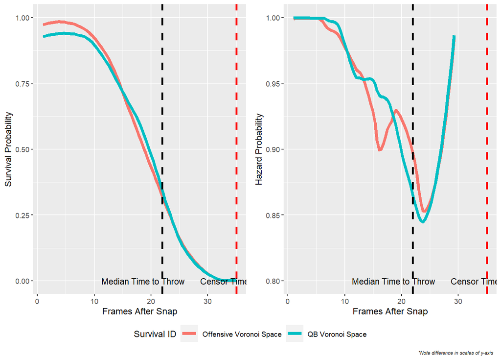

```r
print(surv_fun(summary_analysis_df,det_area_analysis_df,play_info_df,compiled_bin_info_df)[[1]][[1]])
```

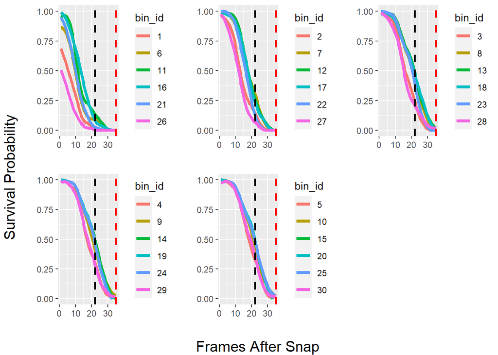

```r
print(surv_fun(summary_analysis_df,det_area_analysis_df,play_info_df,compiled_bin_info_df)[[1]][[2]])
```